# DESCRIPTION

Comcast is an American global telecommunication company. The firm has been providing terrible customer service. They continue to fall short despite repeated promises to improve. Only last month (October 2016) the authority fined them a $2.3 million, after receiving over 1000 consumer complaints. The existing database will serve as a repository of public customer complaints filed against Comcast. It will help to pin down what is wrong with Comcast's customer service.

### Data Dictionary

Ticket #: Ticket number assigned to each complaint Customer Complaint: Description of complaint Date: Date of complaint Time: Time of complaint Received Via: Mode of communication of the complaint City: Customer city State: Customer state Zipcode: Customer zip Status: Status of complaint Filing on behalf of someone

## Analysis Task

To perform these tasks, you can use any of the different Python libraries such as NumPy, SciPy, Pandas, scikit-learn, matplotlib, and BeautifulSoup.

- Import data into Python environment.
- Provide the trend chart for the number of complaints at monthly and daily granularity levels.
- Provide a table with the frequency of complaint types.

Which complaint types are maximum i.e., around internet, network issues, or across any other domains.

Which state has the maximum complaints Which state has the highest percentage of unresolved complaints

The analysis results to be provided with insights wherever applicable.

### Importing Python Environment

```python
import os
```

```python
import pandas as pd
```

```python
os.chdir('C://Users/SUPRIYA/Desktop/AI/datascience')
```

```python
#Reading data as csv file into Python Environment
```

```python
data = pd.read_csv('Comcast_telecom_complaints_data.csv')
```

```python
data
```

|  | Ticket # | Customer Complaint | Date | Date_month_year | Time | Received Via | City | State | Zip code | Status | Filing on Behalf of Someone |
| --- | --- | --- | --- | --- | --- | --- | --- | --- | --- | --- | --- |
| 0 | 250635 | Comcast Cable Internet Speeds | 22-04-15 | 22-Apr-15 | 3:53:50 PM | Customer Care Call | Abingdon | Maryland | 21009 | Closed | No |
| 1 | 223441 | Payment disappear - service got disconnected | 04-08-15 | 04-Aug-15 | 10:22:56 AM | Internet | Acworth | Georgia | 30102 | Closed | No |
| 2 | 242732 | Speed and Service | 18-04-15 | 18-Apr-15 | 9:55:47 AM | Internet | Acworth | Georgia | 30101 | Closed | Yes |
| 3 | 277946 | Comcast Imposed a New Usage Cap of 300GB that ... | 05-07-15 | 05-Jul-15 | 11:59:35 AM | Internet | Acworth | Georgia | 30101 | Open | Yes |
| 4 | 307175 | Comcast not working and no service to boot | 26-05-15 | 26-May-15 | 1:25:26 PM | Internet | Acworth | Georgia | 30101 | Solved | No |
| 5 | 338519 | ISP Charging for arbitrary data limits with ov... | 06-12-15 | 06-Dec-15 | 9:59:40 PM | Internet | Acworth | Georgia | 30101 | Solved | No |
| 6 | 361148 | Throttling service and unreasonable data caps | 24-06-15 | 24-Jun-15 | 10:13:55 AM | Customer Care Call | Acworth | Georgia | 30101 | Pending | No |
| 7 | 359792 | Comcast refuses to help troubleshoot and corre... | 23-06-15 | 23-Jun-15 | 6:56:14 PM | Internet | Adrian | Michigan | 49221 | Solved | No |
| 8 | 318072 | Comcast extended outages | 06-01-15 | 06-Jan-15 | 11:46:30 PM | Customer Care Call | Alameda | California | 94502 | Closed | No |
| 9 | 371214 | Comcast Raising Prices and Not Being Available... | 28-06-15 | 28-Jun-15 | 6:46:31 PM | Customer Care Call | Alameda | California | 94501 | Open | Yes |
| 10 | 255938 | Billing after service was asked to be disconne... | 24-04-15 | 24-Apr-15 | 4:40:36 PM | Internet | Albuquerque | New Mexico | 87106 | Closed | No |
| 11 | 276409 | YAHOO FAILURE TO RESTORE EMAIL SEARCH FEATURE | 05-06-15 | 05-Jun-15 | 3:09:49 PM | Customer Care Call | Albuquerque | New Mexico | 87109 | Closed | No |
| 12 | 339282 | Comcast Violating Open Internet Rules by Block... | 13-06-15 | 13-Jun-15 | 4:03:18 PM | Internet | Albuquerque | New Mexico | 87105 | Open | Yes |
| 13 | 360178 | Internet speed | 23-06-15 | 23-Jun-15 | 9:23:23 PM | Internet | Albuquerque | New Mexico | 87113 | Solved | No |
| 14 | 376268 | Internet Disconnects Every Night | 30-06-15 | 30-Jun-15 | 10:30:02 PM | Customer Care Call | Albuquerque | New Mexico | 87116 | Solved | No |
| 15 | 370137 | Internet complaint | 27-06-15 | 27-Jun-15 | 3:25:03 PM | Customer Care Call | Albuquerqur | New Mexico | 87102 | Pending | No |
| 16 | 363695 | Internet Availability and Speed | 24-06-15 | 24-Jun-15 | 11:47:33 PM | Customer Care Call | Alexandria | Indiana | 46001 | Solved | No |
| 17 | 238694 | Comcast owes me $65 and claims I need to retur... | 16-04-15 | 16-Apr-15 | 10:04:57 AM | Internet | Alexandria | Virginia | 22304 | Closed | No |
| 18 | 230876 | Horrible Internet Service | 04-11-15 | 04-Nov-15 | 7:48:05 PM | Customer Care Call | Alexandria | Virginia | 22305 | Closed | No |
| 19 | 318725 | Failure to provide services that I am billed for. | 06-02-15 | 06-Feb-15 | 1:03:52 PM | Customer Care Call | Alexandria | Virginia | 22314 | Closed | No |
| 20 | 327657 | Internet out all the time but they have a mono... | 06-07-15 | 06-Jul-15 | 8:55:43 PM | Customer Care Call | Alexandria | Virginia | 22305 | Solved | No |
| 21 | 328742 | horrible cable service and customer service | 06-08-15 | 06-Aug-15 | 3:18:58 PM | Internet | Alexandria | Virginia | 22312 | Solved | No |
| 22 | 328165 | Speed | 06-08-15 | 06-Aug-15 | 12:03:37 PM | Customer Care Call | Alexandria | Virginia | 22304 | Solved | No |
| 23 | 370538 | Comcast monopoly bundling practices | 27-06-15 | 27-Jun-15 | 9:04:34 PM | Internet | Alexandria | Virginia | 22304 | Open | No |
| 24 | 370363 | COMCAST! | 27-06-15 | 27-Jun-15 | 6:37:29 PM | Internet | Alexandria | Virginia | 22305 | Solved | No |
| 25 | 270163 | bait and switch | 05-02-15 | 05-Feb-15 | 3:55:24 PM | Internet | Algonquin | Illinois | 60102 | Open | Yes |
| 26 | 355976 | Comcast Customer Service | 22-06-15 | 22-Jun-15 | 2:10:39 PM | Internet | Aliquippa | Pennsylvania | 15001 | Open | No |
| 27 | 260651 | Apartment Management's Exclusivity Contract wi... | 28-04-15 | 28-Apr-15 | 8:01:46 AM | Customer Care Call | Allston | Massachusetts | 2134 | Closed | No |
| 28 | 305340 | Unable to reach a Comcast agent for internet a... | 24-05-15 | 24-May-15 | 2:57:47 PM | Customer Care Call | Aloha | Oregon | 97006 | Solved | No |
| 29 | 360759 | Wifi internet not working as well | 24-06-15 | 24-Jun-15 | 2:23:23 AM | Internet | Aloha | Oregon | 97006 | Pending | No |
| ... | ... | ... | ... | ... | ... | ... | ... | ... | ... | ... | ... |
| 2194 | 270923 | Xfinity corporate bullying, breach of contract | 05-03-15 | 05-Mar-15 | 11:11:40 PM | Customer Care Call | Woodbridge | Virginia | 22191 | Closed | No |
| 2195 | 318189 | I am so fed up with Comcast | 06-02-15 | 06-Feb-15 | 6:52:56 AM | Customer Care Call | Woodbridge | Virginia | 22191 | Closed | No |
| 2196 | 339481 | Terrible internet service from Comcast | 13-06-15 | 13-Jun-15 | 7:14:02 PM | Customer Care Call | Woodbridge | Virginia | 22191 | Open | No |
| 2197 | 360169 | Comcast cramming services I didn't ask for to ... | 23-06-15 | 23-Jun-15 | 9:12:42 PM | Internet | Woodinville | Washington | 98077 | Solved | No |
| 2198 | 359056 | Comcast over charge | 23-06-15 | 23-Jun-15 | 3:47:53 PM | Customer Care Call | Woodinville | Washington | 98077 | Solved | No |
| 2199 | 302816 | charged for no seevice | 22-05-15 | 22-May-15 | 7:17:11 AM | Customer Care Call | Woodridge | Illinois | 60517 | Closed | No |
| 2200 | 245857 | Comcast Xfintity Internet Data Caps | 20-04-15 | 20-Apr-15 | 7:19:07 PM | Internet | Woodstock | Georgia | 30188 | Closed | No |
| 2201 | 259691 | Miss Represented and over charged now | 27-04-15 | 27-Apr-15 | 4:59:36 PM | Customer Care Call | Woodstock | Georgia | 30189 | Closed | No |
| 2202 | 305166 | comcst data cap | 24-05-15 | 24-May-15 | 12:34:08 AM | Customer Care Call | Woodstock | Georgia | 30188 | Open | Yes |
| 2203 | 329247 | Inconsistent and Intermittent Internet Connect... | 06-08-15 | 06-Aug-15 | 6:17:50 PM | Internet | Woodstock | Georgia | 30188 | Solved | No |
| 2204 | 350920 | Comcast will not refund or reimburse significa... | 19-06-15 | 19-Jun-15 | 1:11:27 AM | Internet | Woodstock | Georgia | 30188 | Solved | No |
| 2205 | 357824 | Lied to about install costs | 23-06-15 | 23-Jun-15 | 11:26:08 AM | Customer Care Call | Woodstock | Georgia | 30188 | Solved | No |
| 2206 | 360908 | Issues with Comcast billing and equipment | 24-06-15 | 24-Jun-15 | 8:00:17 AM | Internet | Woodstock | Georgia | 30188 | Solved | No |
| 2207 | 363934 | Comcast Internet | 25-06-15 | 25-Jun-15 | 9:00:09 AM | Internet | Woodstock | Georgia | 30188 | Solved | No |
| 2208 | 374570 | comcast cap | 30-06-15 | 30-Jun-15 | 12:42:45 PM | Customer Care Call | Woodstock | Georgia | 30188 | Pending | No |
| 2209 | 279410 | False Advertising/Bait and switch | 05-07-15 | 05-Jul-15 | 9:47:36 PM | Customer Care Call | Worth | Illinois | 60482 | Solved | No |
| 2210 | 228198 | comcast customer service, and billing issues | 04-10-15 | 04-Oct-15 | 10:15:03 AM | Customer Care Call | Wrightstown | New Jersey | 8562 | Closed | No |
| 2211 | 221763 | Comcast | 04-07-15 | 04-Jul-15 | 1:49:52 PM | Internet | Wyoming | Michigan | 49509 | Closed | No |
| 2212 | 326963 | Internet Services | 06-06-15 | 06-Jun-15 | 4:01:16 PM | Internet | Wyoming | Michigan | 49509 | Closed | No |
| 2213 | 256002 | i had sent out a check payment comcast | 24-04-15 | 24-Apr-15 | 5:05:36 PM | Internet | York | Pennsylvania | 17401 | Closed | No |
| 2214 | 310847 | Comcast Internet Service quality | 28-05-15 | 28-May-15 | 8:56:14 AM | Internet | York | Pennsylvania | 17403 | Solved | No |
| 2215 | 360946 | Comcast unfair pricing | 24-06-15 | 24-Jun-15 | 8:32:24 AM | Customer Care Call | York | Pennsylvania | 17403 | Solved | No |
| 2216 | 363852 | High Internet & Cable Bill | 25-06-15 | 25-Jun-15 | 7:17:21 AM | Customer Care Call | York | Pennsylvania | 17404 | Solved | Yes |
| 2217 | 254488 | problems with internet service | 24-04-15 | 24-Apr-15 | 5:05:25 AM | Internet | York Haven | Pennsylvania | 17370 | Closed | No |
| 2218 | 338192 | Speed throttling, speeds not at promised output | 06-12-15 | 06-Dec-15 | 6:35:59 PM | Customer Care Call | Yorkville | Illinois | 60560 | Open | Yes |
| 2219 | 213550 | Service Availability | 04-02-15 | 04-Feb-15 | 9:13:18 AM | Customer Care Call | Youngstown | Florida | 32466 | Closed | No |
| 2220 | 318775 | Comcast Monthly Billing for Returned Modem | 06-02-15 | 06-Feb-15 | 1:24:39 PM | Customer Care Call | Ypsilanti | Michigan | 48197 | Solved | No |
| 2221 | 331188 | complaint about comcast | 06-09-15 | 06-Sep-15 | 5:28:41 PM | Internet | Ypsilanti | Michigan | 48197 | Solved | No |
| 2222 | 360489 | Extremely unsatisfied Comcast customer | 23-06-15 | 23-Jun-15 | 11:13:30 PM | Customer Care Call | Ypsilanti | Michigan | 48197 | Solved | No |
| 2223 | 363614 | Comcast, Ypsilanti MI Internet Speed | 24-06-15 | 24-Jun-15 | 10:28:33 PM | Customer Care Call | Ypsilanti | Michigan | 48198 | Open | Yes |

2224 rows × 11 columns

```python
data.count()
```

```
Ticket #                       2224
Customer Complaint             2224
Date                           2224
Date_month_year                2224
Time                           2224
Received Via                   2224
City                           2224
State                          2224
Zip code                       2224
Status                         2224
Filing on Behalf of Someone    2224
dtype: int64
```

### Providing the trend chart for the number of complaints at monthly and daily granularity levels.

```python
import pandas as pd
```

```python
import numpy as np
```

```python
import matplotlib.pyplot as plt
```

```python
%matplotlib inline
```

```python
plt.rcParams['figure.figsize'] = [20.0, 10.0]
```

```python
data.isnull().sum()
```

```
Ticket #                       0
Customer Complaint             0
Date                           0
Date_month_year                0
Time                           0
Received Via                   0
City                           0
State                          0
Zip code                       0
Status                         0
Filing on Behalf of Someone    0
dtype: int64
```

```python
data.dtypes
```

```
Ticket #                       object
Customer Complaint             object
Date                           object
Date_month_year                object
Time                           object
Received Via                   object
City                           object
State                          object
Zip code                        int64
Status                         object
Filing on Behalf of Someone    object
dtype: object
```

### Trend chart for the number of complaints at Daily granularity levels.

```python
data['Date'] = pd.to_datetime(data['Date'])
```

```python
data['Date']
```

```
0      2015-04-22
1      2015-04-08
2      2015-04-18
3      2015-05-07
4      2015-05-26
5      2015-06-12
6      2015-06-24
7      2015-06-23
8      2015-06-01
9      2015-06-28
10     2015-04-24
11     2015-05-06
12     2015-06-13
13     2015-06-23
14     2015-06-30
```

[output cut: 47 more lines]

```python
data.dtypes
```

```
Ticket #                               object
Customer Complaint                     object
Date                           datetime64[ns]
Date_month_year                        object
Time                                   object
Received Via                           object
City                                   object
State                                  object
Zip code                                int64
Status                                 object
Filing on Behalf of Someone            object
dtype: object
```

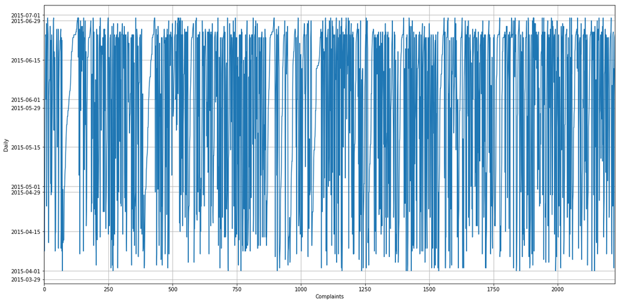

```python
data['Date'].plot(grid=True)
plt.xlabel("Complaints")
plt.ylabel("Daily")
```

### Trend chart for the number of complaints at monthly granularity levels.

```python
Month_Number = data['Date'].dt.month
```

```python
Month=Month_Number.head(100)
```

```python
Month
```

```
0     4
1     4
2     4
3     5
4     5
5     6
6     6
7     6
8     6
9     6
10    4
11    5
12    6
13    6
14    6
```

[output cut: 47 more lines]

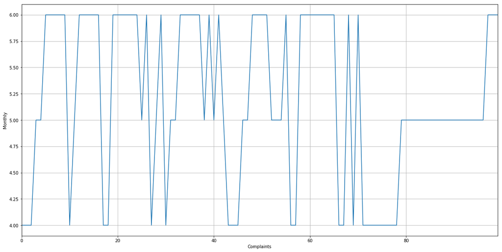

```python
Month.plot(grid=True)
plt.xlabel("Complaints")
plt.ylabel("Monthly")
```

```python
df=pd.DataFrame({'x': range(1,2225), 'y': np.random.randn(2224), 'y1': np.random.randn(2224)+range(1,2225)})
```

[figure not shown]

```python
plt.xlabel("Complaints")
plt.ylabel("Monthly & Daily")
plt.plot( ('x', 'y'), data=df, marker='o', markerfacecolor='blue', label="Month")
plt.plot( ('x', 'y1'), data=df, marker='', color='olive', linewidth=2, label="Day")
#plt.xlim(1, 2224)
#plt.ylim('2015-01-01', '2015-12-31')
plt.legend()
```

### Table for Customer Complaint's with Status

```python
total_frequency=pd.DataFrame(data, columns=['Ticket #','Customer Complaint','Date','Date_month_year','Time','Received Via','City','State','Zip code','Status','Filing on Behalf of Someone'])
```

```python
total_frequency
```

|  | Ticket # | Customer Complaint | Date | Date_month_year | Time | Received Via | City | State | Zip code | Status | Filing on Behalf of Someone |
| --- | --- | --- | --- | --- | --- | --- | --- | --- | --- | --- | --- |
| 0 | 250635 | Comcast Cable Internet Speeds | 2015-04-22 | 22-Apr-15 | 3:53:50 PM | Customer Care Call | Abingdon | Maryland | 21009 | Closed | No |
| 1 | 223441 | Payment disappear - service got disconnected | 2015-04-08 | 04-Aug-15 | 10:22:56 AM | Internet | Acworth | Georgia | 30102 | Closed | No |
| 2 | 242732 | Speed and Service | 2015-04-18 | 18-Apr-15 | 9:55:47 AM | Internet | Acworth | Georgia | 30101 | Closed | Yes |
| 3 | 277946 | Comcast Imposed a New Usage Cap of 300GB that ... | 2015-05-07 | 05-Jul-15 | 11:59:35 AM | Internet | Acworth | Georgia | 30101 | Open | Yes |
| 4 | 307175 | Comcast not working and no service to boot | 2015-05-26 | 26-May-15 | 1:25:26 PM | Internet | Acworth | Georgia | 30101 | Solved | No |
| 5 | 338519 | ISP Charging for arbitrary data limits with ov... | 2015-06-12 | 06-Dec-15 | 9:59:40 PM | Internet | Acworth | Georgia | 30101 | Solved | No |
| 6 | 361148 | Throttling service and unreasonable data caps | 2015-06-24 | 24-Jun-15 | 10:13:55 AM | Customer Care Call | Acworth | Georgia | 30101 | Pending | No |
| 7 | 359792 | Comcast refuses to help troubleshoot and corre... | 2015-06-23 | 23-Jun-15 | 6:56:14 PM | Internet | Adrian | Michigan | 49221 | Solved | No |
| 8 | 318072 | Comcast extended outages | 2015-06-01 | 06-Jan-15 | 11:46:30 PM | Customer Care Call | Alameda | California | 94502 | Closed | No |
| 9 | 371214 | Comcast Raising Prices and Not Being Available... | 2015-06-28 | 28-Jun-15 | 6:46:31 PM | Customer Care Call | Alameda | California | 94501 | Open | Yes |
| 10 | 255938 | Billing after service was asked to be disconne... | 2015-04-24 | 24-Apr-15 | 4:40:36 PM | Internet | Albuquerque | New Mexico | 87106 | Closed | No |
| 11 | 276409 | YAHOO FAILURE TO RESTORE EMAIL SEARCH FEATURE | 2015-05-06 | 05-Jun-15 | 3:09:49 PM | Customer Care Call | Albuquerque | New Mexico | 87109 | Closed | No |
| 12 | 339282 | Comcast Violating Open Internet Rules by Block... | 2015-06-13 | 13-Jun-15 | 4:03:18 PM | Internet | Albuquerque | New Mexico | 87105 | Open | Yes |
| 13 | 360178 | Internet speed | 2015-06-23 | 23-Jun-15 | 9:23:23 PM | Internet | Albuquerque | New Mexico | 87113 | Solved | No |
| 14 | 376268 | Internet Disconnects Every Night | 2015-06-30 | 30-Jun-15 | 10:30:02 PM | Customer Care Call | Albuquerque | New Mexico | 87116 | Solved | No |
| 15 | 370137 | Internet complaint | 2015-06-27 | 27-Jun-15 | 3:25:03 PM | Customer Care Call | Albuquerqur | New Mexico | 87102 | Pending | No |
| 16 | 363695 | Internet Availability and Speed | 2015-06-24 | 24-Jun-15 | 11:47:33 PM | Customer Care Call | Alexandria | Indiana | 46001 | Solved | No |
| 17 | 238694 | Comcast owes me $65 and claims I need to retur... | 2015-04-16 | 16-Apr-15 | 10:04:57 AM | Internet | Alexandria | Virginia | 22304 | Closed | No |
| 18 | 230876 | Horrible Internet Service | 2015-04-11 | 04-Nov-15 | 7:48:05 PM | Customer Care Call | Alexandria | Virginia | 22305 | Closed | No |
| 19 | 318725 | Failure to provide services that I am billed for. | 2015-06-02 | 06-Feb-15 | 1:03:52 PM | Customer Care Call | Alexandria | Virginia | 22314 | Closed | No |
| 20 | 327657 | Internet out all the time but they have a mono... | 2015-06-07 | 06-Jul-15 | 8:55:43 PM | Customer Care Call | Alexandria | Virginia | 22305 | Solved | No |
| 21 | 328742 | horrible cable service and customer service | 2015-06-08 | 06-Aug-15 | 3:18:58 PM | Internet | Alexandria | Virginia | 22312 | Solved | No |
| 22 | 328165 | Speed | 2015-06-08 | 06-Aug-15 | 12:03:37 PM | Customer Care Call | Alexandria | Virginia | 22304 | Solved | No |
| 23 | 370538 | Comcast monopoly bundling practices | 2015-06-27 | 27-Jun-15 | 9:04:34 PM | Internet | Alexandria | Virginia | 22304 | Open | No |
| 24 | 370363 | COMCAST! | 2015-06-27 | 27-Jun-15 | 6:37:29 PM | Internet | Alexandria | Virginia | 22305 | Solved | No |
| 25 | 270163 | bait and switch | 2015-05-02 | 05-Feb-15 | 3:55:24 PM | Internet | Algonquin | Illinois | 60102 | Open | Yes |
| 26 | 355976 | Comcast Customer Service | 2015-06-22 | 22-Jun-15 | 2:10:39 PM | Internet | Aliquippa | Pennsylvania | 15001 | Open | No |
| 27 | 260651 | Apartment Management's Exclusivity Contract wi... | 2015-04-28 | 28-Apr-15 | 8:01:46 AM | Customer Care Call | Allston | Massachusetts | 2134 | Closed | No |
| 28 | 305340 | Unable to reach a Comcast agent for internet a... | 2015-05-24 | 24-May-15 | 2:57:47 PM | Customer Care Call | Aloha | Oregon | 97006 | Solved | No |
| 29 | 360759 | Wifi internet not working as well | 2015-06-24 | 24-Jun-15 | 2:23:23 AM | Internet | Aloha | Oregon | 97006 | Pending | No |
| ... | ... | ... | ... | ... | ... | ... | ... | ... | ... | ... | ... |
| 2194 | 270923 | Xfinity corporate bullying, breach of contract | 2015-05-03 | 05-Mar-15 | 11:11:40 PM | Customer Care Call | Woodbridge | Virginia | 22191 | Closed | No |
| 2195 | 318189 | I am so fed up with Comcast | 2015-06-02 | 06-Feb-15 | 6:52:56 AM | Customer Care Call | Woodbridge | Virginia | 22191 | Closed | No |
| 2196 | 339481 | Terrible internet service from Comcast | 2015-06-13 | 13-Jun-15 | 7:14:02 PM | Customer Care Call | Woodbridge | Virginia | 22191 | Open | No |
| 2197 | 360169 | Comcast cramming services I didn't ask for to ... | 2015-06-23 | 23-Jun-15 | 9:12:42 PM | Internet | Woodinville | Washington | 98077 | Solved | No |
| 2198 | 359056 | Comcast over charge | 2015-06-23 | 23-Jun-15 | 3:47:53 PM | Customer Care Call | Woodinville | Washington | 98077 | Solved | No |
| 2199 | 302816 | charged for no seevice | 2015-05-22 | 22-May-15 | 7:17:11 AM | Customer Care Call | Woodridge | Illinois | 60517 | Closed | No |
| 2200 | 245857 | Comcast Xfintity Internet Data Caps | 2015-04-20 | 20-Apr-15 | 7:19:07 PM | Internet | Woodstock | Georgia | 30188 | Closed | No |
| 2201 | 259691 | Miss Represented and over charged now | 2015-04-27 | 27-Apr-15 | 4:59:36 PM | Customer Care Call | Woodstock | Georgia | 30189 | Closed | No |
| 2202 | 305166 | comcst data cap | 2015-05-24 | 24-May-15 | 12:34:08 AM | Customer Care Call | Woodstock | Georgia | 30188 | Open | Yes |
| 2203 | 329247 | Inconsistent and Intermittent Internet Connect... | 2015-06-08 | 06-Aug-15 | 6:17:50 PM | Internet | Woodstock | Georgia | 30188 | Solved | No |
| 2204 | 350920 | Comcast will not refund or reimburse significa... | 2015-06-19 | 19-Jun-15 | 1:11:27 AM | Internet | Woodstock | Georgia | 30188 | Solved | No |
| 2205 | 357824 | Lied to about install costs | 2015-06-23 | 23-Jun-15 | 11:26:08 AM | Customer Care Call | Woodstock | Georgia | 30188 | Solved | No |
| 2206 | 360908 | Issues with Comcast billing and equipment | 2015-06-24 | 24-Jun-15 | 8:00:17 AM | Internet | Woodstock | Georgia | 30188 | Solved | No |
| 2207 | 363934 | Comcast Internet | 2015-06-25 | 25-Jun-15 | 9:00:09 AM | Internet | Woodstock | Georgia | 30188 | Solved | No |
| 2208 | 374570 | comcast cap | 2015-06-30 | 30-Jun-15 | 12:42:45 PM | Customer Care Call | Woodstock | Georgia | 30188 | Pending | No |
| 2209 | 279410 | False Advertising/Bait and switch | 2015-05-07 | 05-Jul-15 | 9:47:36 PM | Customer Care Call | Worth | Illinois | 60482 | Solved | No |
| 2210 | 228198 | comcast customer service, and billing issues | 2015-04-10 | 04-Oct-15 | 10:15:03 AM | Customer Care Call | Wrightstown | New Jersey | 8562 | Closed | No |
| 2211 | 221763 | Comcast | 2015-04-07 | 04-Jul-15 | 1:49:52 PM | Internet | Wyoming | Michigan | 49509 | Closed | No |
| 2212 | 326963 | Internet Services | 2015-06-06 | 06-Jun-15 | 4:01:16 PM | Internet | Wyoming | Michigan | 49509 | Closed | No |
| 2213 | 256002 | i had sent out a check payment comcast | 2015-04-24 | 24-Apr-15 | 5:05:36 PM | Internet | York | Pennsylvania | 17401 | Closed | No |
| 2214 | 310847 | Comcast Internet Service quality | 2015-05-28 | 28-May-15 | 8:56:14 AM | Internet | York | Pennsylvania | 17403 | Solved | No |
| 2215 | 360946 | Comcast unfair pricing | 2015-06-24 | 24-Jun-15 | 8:32:24 AM | Customer Care Call | York | Pennsylvania | 17403 | Solved | No |
| 2216 | 363852 | High Internet & Cable Bill | 2015-06-25 | 25-Jun-15 | 7:17:21 AM | Customer Care Call | York | Pennsylvania | 17404 | Solved | Yes |
| 2217 | 254488 | problems with internet service | 2015-04-24 | 24-Apr-15 | 5:05:25 AM | Internet | York Haven | Pennsylvania | 17370 | Closed | No |
| 2218 | 338192 | Speed throttling, speeds not at promised output | 2015-06-12 | 06-Dec-15 | 6:35:59 PM | Customer Care Call | Yorkville | Illinois | 60560 | Open | Yes |
| 2219 | 213550 | Service Availability | 2015-04-02 | 04-Feb-15 | 9:13:18 AM | Customer Care Call | Youngstown | Florida | 32466 | Closed | No |
| 2220 | 318775 | Comcast Monthly Billing for Returned Modem | 2015-06-02 | 06-Feb-15 | 1:24:39 PM | Customer Care Call | Ypsilanti | Michigan | 48197 | Solved | No |
| 2221 | 331188 | complaint about comcast | 2015-06-09 | 06-Sep-15 | 5:28:41 PM | Internet | Ypsilanti | Michigan | 48197 | Solved | No |
| 2222 | 360489 | Extremely unsatisfied Comcast customer | 2015-06-23 | 23-Jun-15 | 11:13:30 PM | Customer Care Call | Ypsilanti | Michigan | 48197 | Solved | No |
| 2223 | 363614 | Comcast, Ypsilanti MI Internet Speed | 2015-06-24 | 24-Jun-15 | 10:28:33 PM | Customer Care Call | Ypsilanti | Michigan | 48198 | Open | Yes |

2224 rows × 11 columns

```python
total_frequency.Status.value_counts()
```

```
Solved     973
Closed     734
Open       363
Pending    154
Name: Status, dtype: int64
```

## Creating a new categorical variable with value as Open and Closed. Open & Pending is to be categorized as Open.

### Open & Pending is to be categorized as Open

```python
import numpy as np
```

```python
df=pd.DataFrame(data)
```

```python
open1=df.loc[df['Status'] == 'Open']
```

```python
pending1=df.loc[df['Status'] == 'Pending']
```

```python
result = [open1, pending1]
```

```python
Open = pd.concat(result)
```

```python
Open
```

|  | Ticket # | Customer Complaint | Date | Date_month_year | Time | Received Via | City | State | Zip code | Status | Filing on Behalf of Someone |
| --- | --- | --- | --- | --- | --- | --- | --- | --- | --- | --- | --- |
| 3 | 277946 | Comcast Imposed a New Usage Cap of 300GB that ... | 2015-05-07 | 05-Jul-15 | 11:59:35 AM | Internet | Acworth | Georgia | 30101 | Open | Yes |
| 9 | 371214 | Comcast Raising Prices and Not Being Available... | 2015-06-28 | 28-Jun-15 | 6:46:31 PM | Customer Care Call | Alameda | California | 94501 | Open | Yes |
| 12 | 339282 | Comcast Violating Open Internet Rules by Block... | 2015-06-13 | 13-Jun-15 | 4:03:18 PM | Internet | Albuquerque | New Mexico | 87105 | Open | Yes |
| 23 | 370538 | Comcast monopoly bundling practices | 2015-06-27 | 27-Jun-15 | 9:04:34 PM | Internet | Alexandria | Virginia | 22304 | Open | No |
| 25 | 270163 | bait and switch | 2015-05-02 | 05-Feb-15 | 3:55:24 PM | Internet | Algonquin | Illinois | 60102 | Open | Yes |
| 26 | 355976 | Comcast Customer Service | 2015-06-22 | 22-Jun-15 | 2:10:39 PM | Internet | Aliquippa | Pennsylvania | 15001 | Open | No |
| 38 | 300824 | INTERNET , BILLING AND SERVIE ISSUES | 2015-05-21 | 21-May-15 | 9:34:19 AM | Customer Care Call | Ambridge | Pennsylvania | 15003 | Open | No |
| 39 | 348923 | Comcast blocking DirecTv signals | 2015-06-18 | 18-Jun-15 | 1:50:02 PM | Customer Care Call | Ambridge | Pennsylvania | 15003 | Open | No |
| 40 | 302574 | pmts | 2015-05-21 | 21-May-15 | 8:53:29 PM | Internet | Amesbury | Massachusetts | 1913 | Open | No |
| 41 | 343346 | Slow Internet Speed | 2015-06-16 | 16-Jun-15 | 1:45:58 PM | Internet | Amherst | New Hampshire | 3031 | Open | No |
| 61 | 352100 | Comcast | 2015-06-19 | 19-Jun-15 | 2:36:57 PM | Internet | Arlington | Virginia | 22206 | Open | No |
| 65 | 369398 | without service despite willingness to pay | 2015-06-26 | 26-Jun-15 | 9:09:12 PM | Customer Care Call | Arlington | Virginia | 22204 | Open | No |
| 82 | 278509 | Data caps | 2015-05-07 | 05-Jul-15 | 2:55:45 PM | Internet | Atlanta | Georgia | 30363 | Open | No |
| 84 | 288771 | Comcast Misled With Overage Policy | 2015-05-13 | 13-May-15 | 7:55:53 PM | Internet | Atlanta | Georgia | 30317 | Open | No |
| 88 | 304450 | Data Caps | 2015-05-23 | 23-May-15 | 12:05:55 AM | Internet | Atlanta | Georgia | 30318 | Open | No |
| 89 | 305137 | Comcast disconnecting service before due date | 2015-05-23 | 23-May-15 | 11:34:43 PM | Internet | Atlanta | Georgia | 30324 | Open | No |
| 90 | 305982 | comcast data cap | 2015-05-25 | 25-May-15 | 3:34:56 PM | Internet | Atlanta | Georgia | 30309 | Open | No |
| 96 | 315173 | Comcast discontinuation of service issue | 2015-05-30 | 30-May-15 | 3:27:41 PM | Customer Care Call | Atlanta | Georgia | 30312 | Open | No |
| 106 | 341535 | Comcast Data Usage Charges | 2015-06-15 | 15-Jun-15 | 3:39:09 PM | Customer Care Call | Atlanta | Georgia | 30309 | Open | No |
| 112 | 357856 | Comcast - Billing | 2015-06-23 | 23-Jun-15 | 11:35:54 AM | Customer Care Call | Atlanta | Georgia | 30363 | Open | No |
| 118 | 363616 | COMCAST Poor Customer Service | 2015-06-24 | 24-Jun-15 | 10:28:58 PM | Internet | Atlanta | Georgia | 30345 | Open | No |
| 125 | 363860 | speed | 2015-06-25 | 25-Jun-15 | 7:33:58 AM | Internet | Atlanta | Georgia | 30316 | Open | No |
| 127 | 367718 | Comcast internet and cable service | 2015-06-26 | 26-Jun-15 | 11:02:54 AM | Customer Care Call | Atlanta | Georgia | 30316 | Open | Yes |
| 131 | 375377 | Comcast Support Unable to Provide Accurate Inf... | 2015-06-30 | 30-Jun-15 | 4:17:34 PM | Internet | Atlanta | Georgia | 30328 | Open | No |
| 136 | 274956 | Internet connection both upload and download s... | 2015-05-05 | 05-May-15 | 7:34:03 PM | Customer Care Call | Attica | Indiana | 47918 | Open | No |
| 137 | 338651 | Internet Availability | 2015-06-13 | 13-Jun-15 | 1:07:20 AM | Internet | Attica | Michigan | 48412 | Open | No |
| 140 | 346885 | Comcast | 2015-06-17 | 17-Jun-15 | 6:17:59 PM | Internet | Auburn | Washington | 98092 | Open | No |
| 150 | 342399 | Incorrect prices for new customers | 2015-06-15 | 15-Jun-15 | 9:50:41 PM | Customer Care Call | Aurora | Illinois | 60503 | Open | No |
| 152 | 363993 | Internet Pricing | 2015-06-25 | 25-Jun-15 | 9:30:43 AM | Customer Care Call | Aurora | Illinois | 60502 | Open | No |
| 155 | 347937 | Comcast throttles internet | 2015-06-18 | 18-Jun-15 | 9:15:45 AM | Customer Care Call | Austin | Texas | 78731 | Open | No |
| ... | ... | ... | ... | ... | ... | ... | ... | ... | ... | ... | ... |
| 1846 | 359832 | Outrageous billing costs and Data caps | 2015-06-23 | 23-Jun-15 | 7:09:44 PM | Internet | Savannah | Georgia | 31401 | Pending | No |
| 1849 | 371792 | Bait and switch service | 2015-06-29 | 29-Jun-15 | 11:13:48 AM | Customer Care Call | Savannah | Georgia | 31401 | Pending | No |
| 1885 | 376228 | Comcast/Xfinity Internet Data Cap | 2015-06-30 | 30-Jun-15 | 10:06:30 PM | Internet | Senoia | Georgia | 30276 | Pending | No |
| 1886 | 371378 | threat of shutting off service of phone,intern... | 2015-06-28 | 28-Jun-15 | 11:02:02 PM | Internet | Sharon | Connecticut | 6069 | Pending | No |
| 1907 | 373980 | Comcast 300GB CAP | 2015-06-30 | 30-Jun-15 | 8:15:55 AM | Customer Care Call | Smyrna | Georgia | 30080 | Pending | No |
| 1911 | 315515 | continue to be scared by comcast | 2015-05-30 | 30-May-15 | 11:58:23 PM | Internet | Snellville | Georgia | 30078 | Pending | No |
| 1964 | 363649 | Poor Quality Service and Broken Promises | 2015-06-24 | 24-Jun-15 | 10:54:37 PM | Customer Care Call | Springfield | Oregon | 97477 | Pending | No |
| 1970 | 313370 | Comcast - HBO - PS3 | 2015-05-29 | 29-May-15 | 12:44:16 PM | Internet | St Paul | Minnesota | 55104 | Pending | No |
| 1983 | 361383 | Billing Overcharging Issues By Comcast | 2015-06-24 | 24-Jun-15 | 11:14:43 AM | Internet | Sterling Hts | Michigan | 48310 | Pending | No |
| 1984 | 359099 | Internet Speed Cut in Half with no Notification | 2015-06-23 | 23-Jun-15 | 3:55:31 PM | Internet | Stevensville | Michigan | 49127 | Pending | No |
| 1985 | 337660 | internet access | 2015-06-12 | 06-Dec-15 | 4:23:28 PM | Customer Care Call | Stillwater | Minnesota | 55082 | Pending | No |
| 1987 | 362576 | Comcast Data Cap | 2015-06-24 | 24-Jun-15 | 4:04:24 PM | Customer Care Call | Stockbridge | Georgia | 30281 | Pending | No |
| 2014 | 369563 | comcast data caps | 2015-06-27 | 27-Jun-15 | 12:33:29 AM | Internet | Suwanee | Georgia | 30038 | Pending | No |
| 2053 | 375640 | Comcast service complaint | 2015-06-30 | 30-Jun-15 | 5:26:53 PM | Internet | Troy | Michigan | 48083 | Pending | No |
| 2071 | 360586 | Tucson Comcast Data Caps on Internet Service | 2015-06-24 | 24-Jun-15 | 12:03:41 AM | Customer Care Call | Tucson | Arizona | 85718 | Pending | No |
| 2072 | 363735 | Data Cap | 2015-06-25 | 25-Jun-15 | 12:36:03 AM | Customer Care Call | Tucson | Arizona | 85742 | Pending | No |
| 2073 | 363773 | Home Internet Data Caps | 2015-06-25 | 25-Jun-15 | 2:07:29 AM | Internet | Tucson | Arizona | 85741 | Pending | No |
| 2075 | 367324 | Data usage cap with Comcast Xfinity | 2015-06-26 | 26-Jun-15 | 1:53:47 AM | Internet | Tucson | Arizona | 85750 | Pending | No |
| 2077 | 374566 | Comcast Data Usage Plan Trial | 2015-06-30 | 30-Jun-15 | 12:42:23 PM | Internet | Tupelo | Mississippi | 38804 | Pending | No |
| 2080 | 360717 | Comcast Data Caps and Throttling | 2015-06-24 | 24-Jun-15 | 1:31:17 AM | Customer Care Call | Tuscaloosa | Alabama | 35401 | Pending | No |
| 2083 | 310832 | Comcast issues don't get resolved | 2015-05-28 | 28-May-15 | 8:35:51 AM | Internet | Union City | Georgia | 30291 | Pending | No |
| 2085 | 356764 | shitty comcast | 2015-06-22 | 22-Jun-15 | 5:52:29 PM | Customer Care Call | Urbana | Illinois | 61801 | Pending | No |
| 2086 | 359468 | shitty comcast service | 2015-06-23 | 23-Jun-15 | 5:20:00 PM | Customer Care Call | Urbana | Illinois | 61801 | Pending | No |
| 2108 | 360535 | Comcast Internet | 2015-06-23 | 23-Jun-15 | 11:31:13 PM | Internet | Walnut Creek | California | 94596 | Pending | No |
| 2121 | 306239 | Credit on Bill and Change of Service Request | 2015-05-25 | 25-May-15 | 9:56:13 PM | Customer Care Call | Washington | District Of Columbia | 20010 | Pending | No |
| 2161 | 375388 | Comcast Data Cap Overage Fees | 2015-06-30 | 30-Jun-15 | 4:19:50 PM | Internet | West Monroe | Louisiana | 71291 | Pending | No |
| 2173 | 366969 | Internet speed | 2015-06-25 | 25-Jun-15 | 8:05:35 PM | Internet | Wexford | Pennsylvania | 15090 | Pending | No |
| 2184 | 360304 | Throttling Internet | 2015-06-23 | 23-Jun-15 | 10:11:23 PM | Internet | Wilmington | Delaware | 19802 | Pending | No |
| 2186 | 312486 | data usage caps | 2015-05-28 | 28-May-15 | 7:10:58 PM | Customer Care Call | Winder | Georgia | 30680 | Pending | No |
| 2208 | 374570 | comcast cap | 2015-06-30 | 30-Jun-15 | 12:42:45 PM | Customer Care Call | Woodstock | Georgia | 30188 | Pending | No |

517 rows × 11 columns

### Closed & Solved is to be categorized as Closed.

```python
solved1=df.loc[df['Status'] == 'Solved']
```

```python
closed1=df.loc[df['Status'] == 'Closed']
```

```python
result = [solved1, closed1]
```

```python
Closed = pd.concat(result)
```

```python
Closed
```

|  | Ticket # | Customer Complaint | Date | Date_month_year | Time | Received Via | City | State | Zip code | Status | Filing on Behalf of Someone |
| --- | --- | --- | --- | --- | --- | --- | --- | --- | --- | --- | --- |
| 4 | 307175 | Comcast not working and no service to boot | 2015-05-26 | 26-May-15 | 1:25:26 PM | Internet | Acworth | Georgia | 30101 | Solved | No |
| 5 | 338519 | ISP Charging for arbitrary data limits with ov... | 2015-06-12 | 06-Dec-15 | 9:59:40 PM | Internet | Acworth | Georgia | 30101 | Solved | No |
| 7 | 359792 | Comcast refuses to help troubleshoot and corre... | 2015-06-23 | 23-Jun-15 | 6:56:14 PM | Internet | Adrian | Michigan | 49221 | Solved | No |
| 13 | 360178 | Internet speed | 2015-06-23 | 23-Jun-15 | 9:23:23 PM | Internet | Albuquerque | New Mexico | 87113 | Solved | No |
| 14 | 376268 | Internet Disconnects Every Night | 2015-06-30 | 30-Jun-15 | 10:30:02 PM | Customer Care Call | Albuquerque | New Mexico | 87116 | Solved | No |
| 16 | 363695 | Internet Availability and Speed | 2015-06-24 | 24-Jun-15 | 11:47:33 PM | Customer Care Call | Alexandria | Indiana | 46001 | Solved | No |
| 20 | 327657 | Internet out all the time but they have a mono... | 2015-06-07 | 06-Jul-15 | 8:55:43 PM | Customer Care Call | Alexandria | Virginia | 22305 | Solved | No |
| 21 | 328742 | horrible cable service and customer service | 2015-06-08 | 06-Aug-15 | 3:18:58 PM | Internet | Alexandria | Virginia | 22312 | Solved | No |
| 22 | 328165 | Speed | 2015-06-08 | 06-Aug-15 | 12:03:37 PM | Customer Care Call | Alexandria | Virginia | 22304 | Solved | No |
| 24 | 370363 | COMCAST! | 2015-06-27 | 27-Jun-15 | 6:37:29 PM | Internet | Alexandria | Virginia | 22305 | Solved | No |
| 28 | 305340 | Unable to reach a Comcast agent for internet a... | 2015-05-24 | 24-May-15 | 2:57:47 PM | Customer Care Call | Aloha | Oregon | 97006 | Solved | No |
| 31 | 296608 | Comcast Internet Data Cap | 2015-05-19 | 19-May-15 | 10:56:20 AM | Internet | Alpharetta | Georgia | 30022 | Solved | No |
| 32 | 310990 | XFINITY Movers Edge program | 2015-05-28 | 28-May-15 | 10:37:13 AM | Customer Care Call | Alpharetta | Georgia | 30022 | Solved | No |
| 33 | 325342 | Comcast Data Internet Usage | 2015-06-05 | 06-May-15 | 1:25:58 PM | Internet | Alpharetta | Georgia | 30022 | Solved | No |
| 34 | 337489 | Comcast not refunding my credit | 2015-06-12 | 06-Dec-15 | 3:59:57 PM | Internet | Alpharetta | Georgia | 30005 | Solved | No |
| 35 | 354116 | Comcast | 2015-06-20 | 20-Jun-15 | 5:03:09 PM | Internet | Alpharetta | Georgia | 30022 | Solved | No |
| 37 | 373874 | Comcast | 2015-06-30 | 30-Jun-15 | 12:24:57 AM | Customer Care Call | Alvin | Texas | 77511 | Solved | No |
| 42 | 286768 | not getting what I am paying for with internet | 2015-05-12 | 05-Dec-15 | 9:06:01 PM | Customer Care Call | Andover | Minnesota | 55304 | Solved | No |
| 47 | 309379 | Comcast | 2015-05-27 | 27-May-15 | 1:50:37 PM | Internet | Ann Arbor | Michigan | 48105 | Solved | No |
| 48 | 351079 | Comcast Billing and Service Issues | 2015-06-19 | 19-Jun-15 | 9:19:46 AM | Internet | Ann Arbor | Michigan | 48105 | Solved | No |
| 49 | 366705 | Cable prices rising | 2015-06-25 | 25-Jun-15 | 6:17:58 PM | Internet | Ann Arbor | Michigan | 48103 | Solved | No |
| 50 | 368705 | service issues | 2015-06-26 | 26-Jun-15 | 3:56:18 PM | Internet | Annapolis | Maryland | 21401 | Solved | No |
| 51 | 347369 | HBO GO on Playstation 4 | 2015-06-17 | 17-Jun-15 | 8:41:23 PM | Internet | Annville | Pennsylvania | 17003 | Solved | No |
| 52 | 291784 | internet connectivity | 2015-05-15 | 15-May-15 | 1:07:11 PM | Customer Care Call | Anoka | Minnesota | 55303 | Solved | No |
| 53 | 308478 | Email issues | 2015-05-26 | 26-May-15 | 9:45:02 PM | Customer Care Call | Antioch | California | 94509 | Solved | No |
| 54 | 309851 | Monopoly | 2015-05-27 | 27-May-15 | 4:24:46 PM | Internet | Antioch | Tennessee | 37013 | Solved | No |
| 59 | 342435 | Issues with Comcast | 2015-06-15 | 15-Jun-15 | 10:39:15 PM | Internet | Arlington | Virginia | 22206 | Solved | No |
| 60 | 348514 | Comcast Refuses to Schedule a Future Service S... | 2015-06-18 | 18-Jun-15 | 12:02:57 PM | Internet | Arlington | Virginia | 22204 | Solved | No |
| 62 | 355887 | Overbilling | 2015-06-22 | 22-Jun-15 | 1:45:40 PM | Customer Care Call | Arlington | Virginia | 22207 | Solved | Yes |
| 63 | 356118 | Comcast - failure to provide service, refusal ... | 2015-06-22 | 22-Jun-15 | 2:41:05 PM | Customer Care Call | Arlington | Virginia | 22206 | Solved | No |
| ... | ... | ... | ... | ... | ... | ... | ... | ... | ... | ... | ... |
| 2143 | 213198 | Fradulent Services | 2015-04-01 | 04-Jan-15 | 8:56:38 PM | Customer Care Call | Waukegan | Illinois | 60085 | Closed | No |
| 2144 | 211677 | Comcast refusal of service | 2015-04-01 | 04-Jan-15 | 12:01:06 PM | Customer Care Call | Wayne | Pennsylvania | 19087 | Closed | No |
| 2145 | 370429 | (Comcast is not my complaint!) Cyber Tele-mark... | 2015-06-27 | 27-Jun-15 | 7:04:11 PM | Customer Care Call | Weirton | West Virginia | 26062 | Closed | No |
| 2150 | 231419 | over sold/ over billed for short term services | 2015-04-12 | 04-Dec-15 | 7:39:11 PM | Customer Care Call | Wenonah | New Jersey | 8090 | Closed | No |
| 2151 | 230991 | Misrepresentation of Internet Speed | 2015-04-11 | 04-Nov-15 | 11:04:52 PM | Customer Care Call | West Chester | Pennsylvania | 19382 | Closed | No |
| 2152 | 324821 | Comcast Home Security System | 2015-06-05 | 06-May-15 | 10:08:04 AM | Customer Care Call | West Chester | Pennsylvania | 19382 | Closed | No |
| 2155 | 221993 | Comcast is giving out wrong information, accus... | 2015-04-07 | 04-Jul-15 | 2:44:49 PM | Internet | West Hartford | Connecticut | 6110 | Closed | No |
| 2156 | 228557 | unauthorized charges to my account by comcast | 2015-04-10 | 04-Oct-15 | 12:09:47 PM | Internet | West Lafayette | Indiana | 47906 | Closed | No |
| 2160 | 368991 | CRAMMING, False Internet Promotion, SPEED comp... | 2015-06-26 | 26-Jun-15 | 5:33:39 PM | Customer Care Call | West Monroe | Louisiana | 71291 | Closed | Yes |
| 2162 | 257843 | Comcast committing extortion | 2015-04-26 | 26-Apr-15 | 4:50:27 PM | Internet | West Palm Beach | Florida | 33401 | Closed | No |
| 2164 | 310997 | overbilled | 2015-05-28 | 28-May-15 | 10:41:30 AM | Customer Care Call | West Palm Beach | Florida | 33401 | Closed | No |
| 2172 | 306258 | Comcast Xfinity | 2015-05-25 | 25-May-15 | 10:39:21 PM | Customer Care Call | Weston | Florida | 33327 | Closed | No |
| 2175 | 370248 | Comcast Failing to Show up to scheduled appoin... | 2015-06-27 | 27-Jun-15 | 4:32:12 PM | Customer Care Call | Wheaton | Illinois | 60189 | Closed | No |
| 2178 | 316632 | internet provider | 2015-06-01 | 06-Jan-15 | 12:36:03 PM | Internet | Willingboro | New Jersey | 8046 | Closed | No |
| 2179 | 232360 | slow internet | 2015-04-13 | 13-Apr-15 | 2:04:01 PM | Customer Care Call | Willis | Michigan | 48191 | Closed | No |
| 2180 | 247649 | Comcast | 2015-04-21 | 21-Apr-15 | 2:04:59 PM | Internet | Wilmington | Delaware | 19805 | Closed | Yes |
| 2181 | 258204 | Comcast cramming | 2015-04-27 | 27-Apr-15 | 8:50:47 AM | Internet | Wilmington | Delaware | 19803 | Closed | No |
| 2190 | 222759 | monopolistic billing practices | 2015-04-07 | 04-Jul-15 | 6:57:54 PM | Customer Care Call | Winnetka | Illinois | 60093 | Closed | No |
| 2191 | 249325 | Comcast Outage | 2015-04-22 | 22-Apr-15 | 12:28:39 AM | Customer Care Call | Wise | Virginia | 24293 | Closed | Yes |
| 2194 | 270923 | Xfinity corporate bullying, breach of contract | 2015-05-03 | 05-Mar-15 | 11:11:40 PM | Customer Care Call | Woodbridge | Virginia | 22191 | Closed | No |
| 2195 | 318189 | I am so fed up with Comcast | 2015-06-02 | 06-Feb-15 | 6:52:56 AM | Customer Care Call | Woodbridge | Virginia | 22191 | Closed | No |
| 2199 | 302816 | charged for no seevice | 2015-05-22 | 22-May-15 | 7:17:11 AM | Customer Care Call | Woodridge | Illinois | 60517 | Closed | No |
| 2200 | 245857 | Comcast Xfintity Internet Data Caps | 2015-04-20 | 20-Apr-15 | 7:19:07 PM | Internet | Woodstock | Georgia | 30188 | Closed | No |
| 2201 | 259691 | Miss Represented and over charged now | 2015-04-27 | 27-Apr-15 | 4:59:36 PM | Customer Care Call | Woodstock | Georgia | 30189 | Closed | No |
| 2210 | 228198 | comcast customer service, and billing issues | 2015-04-10 | 04-Oct-15 | 10:15:03 AM | Customer Care Call | Wrightstown | New Jersey | 8562 | Closed | No |
| 2211 | 221763 | Comcast | 2015-04-07 | 04-Jul-15 | 1:49:52 PM | Internet | Wyoming | Michigan | 49509 | Closed | No |
| 2212 | 326963 | Internet Services | 2015-06-06 | 06-Jun-15 | 4:01:16 PM | Internet | Wyoming | Michigan | 49509 | Closed | No |
| 2213 | 256002 | i had sent out a check payment comcast | 2015-04-24 | 24-Apr-15 | 5:05:36 PM | Internet | York | Pennsylvania | 17401 | Closed | No |
| 2217 | 254488 | problems with internet service | 2015-04-24 | 24-Apr-15 | 5:05:25 AM | Internet | York Haven | Pennsylvania | 17370 | Closed | No |
| 2219 | 213550 | Service Availability | 2015-04-02 | 04-Feb-15 | 9:13:18 AM | Customer Care Call | Youngstown | Florida | 32466 | Closed | No |

1707 rows × 11 columns

```python
q3=data.describe()
```

```python
q3
```

|  | Zip code |
| --- | --- |
| count | 2224.000000 |
| mean | 47994.393435 |
| std | 28885.279427 |
| min | 1075.000000 |
| 25% | 30056.500000 |
| 50% | 37211.000000 |
| 75% | 77058.750000 |
| max | 99223.000000 |

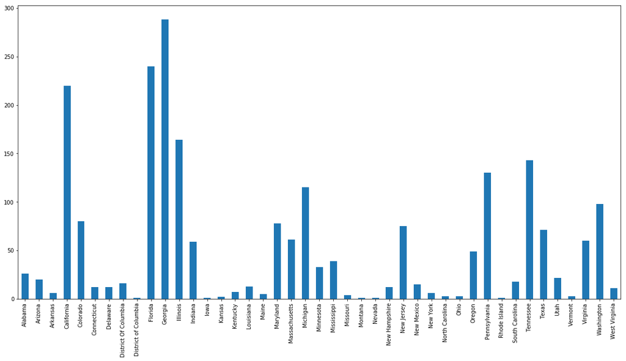

```python
data['State'].value_counts().sort_index().plot.bar()
```

### The state has the maximum complaints

```python
All_states_complaints=data.State.value_counts()
```

```python
All_states_complaints
```

```
Georgia                 288
Florida                 240
California              220
Illinois                164
Tennessee               143
Pennsylvania            130
Michigan                115
Washington               98
Colorado                 80
Maryland                 78
New Jersey               75
Texas                    71
Massachusetts            61
Virginia                 60
Indiana                  59
Oregon                   49
Mississippi              39
Minnesota                33
Alabama                  26
Utah                     22
Arizona                  20
South Carolina           18
District Of Columbia     16
New Mexico               15
Louisiana                13
Connecticut              12
New Hampshire            12
Delaware                 12
West Virginia            11
Kentucky                  7
Arkansas                  6
New York                  6
Maine                     5
Missouri                  4
Vermont                   3
North Carolina            3
Ohio                      3
Kansas                    2
Nevada                    1
Iowa                      1
Montana                   1
District of Columbia      1
Rhode Island              1
Name: State, dtype: int64
```

```python
max_state_count=All_states_complaints.max()
print ("The State which has maximum complaints is : " + str(All_states_complaints)[0:20] +str(max_state_count))
```

```
The State which has maximum complaints is : Georgia             288
```

### The state which has the highest percentage of unresolved complaints

```python
df1=pd.DataFrame(Open)
```

#### The complaints which are received through the Customer Care Call

```python
customer_calls = df1.loc[df1['Received Via'] == 'Customer Care Call']
```

```python
customer_calls
```

|  | Ticket # | Customer Complaint | Date | Date_month_year | Time | Received Via | City | State | Zip code | Status | Filing on Behalf of Someone |
| --- | --- | --- | --- | --- | --- | --- | --- | --- | --- | --- | --- |
| 9 | 371214 | Comcast Raising Prices and Not Being Available... | 2015-06-28 | 28-Jun-15 | 6:46:31 PM | Customer Care Call | Alameda | California | 94501 | Open | Yes |
| 38 | 300824 | INTERNET , BILLING AND SERVIE ISSUES | 2015-05-21 | 21-May-15 | 9:34:19 AM | Customer Care Call | Ambridge | Pennsylvania | 15003 | Open | No |
| 39 | 348923 | Comcast blocking DirecTv signals | 2015-06-18 | 18-Jun-15 | 1:50:02 PM | Customer Care Call | Ambridge | Pennsylvania | 15003 | Open | No |
| 65 | 369398 | without service despite willingness to pay | 2015-06-26 | 26-Jun-15 | 9:09:12 PM | Customer Care Call | Arlington | Virginia | 22204 | Open | No |
| 96 | 315173 | Comcast discontinuation of service issue | 2015-05-30 | 30-May-15 | 3:27:41 PM | Customer Care Call | Atlanta | Georgia | 30312 | Open | No |
| 106 | 341535 | Comcast Data Usage Charges | 2015-06-15 | 15-Jun-15 | 3:39:09 PM | Customer Care Call | Atlanta | Georgia | 30309 | Open | No |
| 112 | 357856 | Comcast - Billing | 2015-06-23 | 23-Jun-15 | 11:35:54 AM | Customer Care Call | Atlanta | Georgia | 30363 | Open | No |
| 127 | 367718 | Comcast internet and cable service | 2015-06-26 | 26-Jun-15 | 11:02:54 AM | Customer Care Call | Atlanta | Georgia | 30316 | Open | Yes |
| 136 | 274956 | Internet connection both upload and download s... | 2015-05-05 | 05-May-15 | 7:34:03 PM | Customer Care Call | Attica | Indiana | 47918 | Open | No |
| 150 | 342399 | Incorrect prices for new customers | 2015-06-15 | 15-Jun-15 | 9:50:41 PM | Customer Care Call | Aurora | Illinois | 60503 | Open | No |
| 152 | 363993 | Internet Pricing | 2015-06-25 | 25-Jun-15 | 9:30:43 AM | Customer Care Call | Aurora | Illinois | 60502 | Open | No |
| 155 | 347937 | Comcast throttles internet | 2015-06-18 | 18-Jun-15 | 9:15:45 AM | Customer Care Call | Austin | Texas | 78731 | Open | No |
| 157 | 279378 | Forced Bundling of Internet Service with CATV | 2015-05-07 | 05-Jul-15 | 9:16:13 PM | Customer Care Call | Ayer | Massachusetts | 1432 | Open | No |
| 165 | 252368 | I AM BEING CHARGE DOUBLE FOR MY CABLE BILL. | 2015-04-23 | 23-Apr-15 | 12:56:29 PM | Customer Care Call | Baltimore | Maryland | 21207 | Open | No |
| 167 | 312881 | unauthorized comcast username setup | 2015-05-29 | 29-May-15 | 6:31:23 AM | Customer Care Call | Baltimore | Maryland | 21206 | Open | No |
| 169 | 342923 | Comcast does not disclose the Internet speed I... | 2015-06-16 | 16-Jun-15 | 11:17:13 AM | Customer Care Call | Baltimore | Maryland | 21218 | Open | No |
| 185 | 270364 | No internet, no cable | 2015-05-02 | 05-Feb-15 | 9:14:09 PM | Customer Care Call | Barrington | Illinois | 60010 | Open | No |
| 189 | 327139 | Data Usage Cap Maine | 2015-06-06 | 06-Jun-15 | 8:04:42 PM | Customer Care Call | Bath | Maine | 4530 | Open | No |
| 195 | 252877 | Comcast Charges | 2015-04-23 | 23-Apr-15 | 3:20:54 PM | Customer Care Call | Beaverton | Oregon | 97005 | Open | No |
| 227 | 347021 | COMPLAINT AGAINST COMCAST | 2015-06-17 | 17-Jun-15 | 6:54:21 PM | Customer Care Call | Bloomfield | Michigan | 48302 | Open | No |
| 244 | 292598 | Billing for equipment that was not provided to me | 2015-05-15 | 15-May-15 | 5:48:59 PM | Customer Care Call | Boca Raton | Florida | 33496 | Open | No |
| 245 | 294846 | Comcast Speed Issues | 2015-05-18 | 18-May-15 | 12:52:13 PM | Customer Care Call | Boca Raton | Florida | 33434 | Open | No |
| 248 | 370148 | Comcast disconnected my account without reason... | 2015-06-27 | 27-Jun-15 | 3:36:57 PM | Customer Care Call | Boca Raton | Florida | 33486 | Open | No |
| 253 | 315491 | bait and switch pricing | 2015-05-30 | 30-May-15 | 10:38:41 PM | Customer Care Call | Bordentown | New Jersey | 8505 | Open | No |
| 276 | 354359 | Comcast Slow Internet | 2015-06-20 | 20-Jun-15 | 10:01:52 PM | Customer Care Call | Brentwood | California | 94513 | Open | No |
| 279 | 358373 | lack of service from comcast | 2015-06-23 | 23-Jun-15 | 1:33:50 PM | Customer Care Call | Brick | New Jersey | 8724 | Open | No |
| 286 | 370683 | Comcast Throttling My Internet | 2015-06-28 | 28-Jun-15 | 1:04:39 AM | Customer Care Call | Brighton | Colorado | 80602 | Open | No |
| 324 | 340458 | Comcast Incompetence/Lies/Robbery | 2015-06-15 | 15-Jun-15 | 9:14:44 AM | Customer Care Call | Cambridge | Massachusetts | 2138 | Open | No |
| 332 | 300123 | Comcast internet | 2015-05-20 | 20-May-15 | 5:47:44 PM | Customer Care Call | Canton | Georgia | 30114 | Open | No |
| 348 | 363169 | Price and performance manipulation by Comcast ... | 2015-06-24 | 24-Jun-15 | 6:46:43 PM | Customer Care Call | Carmel | California | 93923 | Open | No |
| ... | ... | ... | ... | ... | ... | ... | ... | ... | ... | ... | ... |
| 1074 | 353784 | Comcast Data Usage | 2015-06-20 | 20-Jun-15 | 1:09:23 PM | Customer Care Call | Knoxville | Tennessee | 37919 | Pending | No |
| 1329 | 370929 | COMCAST DATA CAP IS BULLCRAP | 2015-06-28 | 28-Jun-15 | 1:37:22 PM | Customer Care Call | Morrow | Georgia | 30260 | Pending | No |
| 1351 | 315373 | Comcast | 2015-05-30 | 30-May-15 | 6:59:10 PM | Customer Care Call | Murfreesboro | Tennessee | 37129 | Pending | No |
| 1399 | 368055 | comcast data cap | 2015-06-26 | 26-Jun-15 | 12:41:14 PM | Customer Care Call | Nashville | Tennessee | 37209 | Pending | No |
| 1422 | 370502 | Comcast Throttling my Internet Connection | 2015-06-27 | 27-Jun-15 | 8:17:48 PM | Customer Care Call | Norristown | Pennsylvania | 19401 | Pending | No |
| 1499 | 359239 | Data Cap Limitations | 2015-06-23 | 23-Jun-15 | 4:25:09 PM | Customer Care Call | Paducah | Kentucky | 42003 | Pending | No |
| 1516 | 360349 | Slow Internet Speeds | 2015-06-23 | 23-Jun-15 | 10:23:39 PM | Customer Care Call | Patterson | California | 95363 | Pending | Yes |
| 1532 | 361391 | Comcast Data Cap | 2015-06-24 | 24-Jun-15 | 11:16:59 AM | Customer Care Call | Petal | Mississippi | 39465 | Pending | No |
| 1568 | 360394 | Comcast's Unfair Billing and Pricing Practices | 2015-06-23 | 23-Jun-15 | 10:44:41 PM | Customer Care Call | Pittsburgh | Pennsylvania | 15205 | Pending | No |
| 1605 | 357139 | Comcast Internet Data Cap | 2015-06-22 | 22-Jun-15 | 8:55:15 PM | Customer Care Call | Pooler | Georgia | 31322 | Pending | No |
| 1649 | 369648 | Comcast Throttling | 2015-06-27 | 27-Jun-15 | 8:24:30 AM | Customer Care Call | Quincy | Massachusetts | 2170 | Pending | Yes |
| 1684 | 358361 | Data Cap on Internet Downloads? | 2015-06-23 | 23-Jun-15 | 1:32:15 PM | Customer Care Call | Rincon | Georgia | 31326 | Pending | No |
| 1730 | 360778 | Comcast speed throttling internet | 2015-06-24 | 24-Jun-15 | 2:41:23 AM | Customer Care Call | Sacramento | California | 95828 | Pending | No |
| 1731 | 367371 | Possible throttle | 2015-06-26 | 26-Jun-15 | 4:40:18 AM | Customer Care Call | Sacramento | California | 95826 | Pending | No |
| 1732 | 373782 | throttling and disconnections | 2015-06-29 | 29-Jun-15 | 10:15:02 PM | Customer Care Call | Sacramento | California | 95828 | Pending | Yes |
| 1773 | 368787 | Awful Internet | 2015-06-26 | 26-Jun-15 | 4:24:07 PM | Customer Care Call | San Francisco | California | 94110 | Pending | No |
| 1834 | 373855 | Throttled connection at peak time | 2015-06-30 | 30-Jun-15 | 12:00:57 AM | Customer Care Call | Santa Maria | California | 93458 | Pending | No |
| 1849 | 371792 | Bait and switch service | 2015-06-29 | 29-Jun-15 | 11:13:48 AM | Customer Care Call | Savannah | Georgia | 31401 | Pending | No |
| 1907 | 373980 | Comcast 300GB CAP | 2015-06-30 | 30-Jun-15 | 8:15:55 AM | Customer Care Call | Smyrna | Georgia | 30080 | Pending | No |
| 1964 | 363649 | Poor Quality Service and Broken Promises | 2015-06-24 | 24-Jun-15 | 10:54:37 PM | Customer Care Call | Springfield | Oregon | 97477 | Pending | No |
| 1985 | 337660 | internet access | 2015-06-12 | 06-Dec-15 | 4:23:28 PM | Customer Care Call | Stillwater | Minnesota | 55082 | Pending | No |
| 1987 | 362576 | Comcast Data Cap | 2015-06-24 | 24-Jun-15 | 4:04:24 PM | Customer Care Call | Stockbridge | Georgia | 30281 | Pending | No |
| 2071 | 360586 | Tucson Comcast Data Caps on Internet Service | 2015-06-24 | 24-Jun-15 | 12:03:41 AM | Customer Care Call | Tucson | Arizona | 85718 | Pending | No |
| 2072 | 363735 | Data Cap | 2015-06-25 | 25-Jun-15 | 12:36:03 AM | Customer Care Call | Tucson | Arizona | 85742 | Pending | No |
| 2080 | 360717 | Comcast Data Caps and Throttling | 2015-06-24 | 24-Jun-15 | 1:31:17 AM | Customer Care Call | Tuscaloosa | Alabama | 35401 | Pending | No |
| 2085 | 356764 | shitty comcast | 2015-06-22 | 22-Jun-15 | 5:52:29 PM | Customer Care Call | Urbana | Illinois | 61801 | Pending | No |
| 2086 | 359468 | shitty comcast service | 2015-06-23 | 23-Jun-15 | 5:20:00 PM | Customer Care Call | Urbana | Illinois | 61801 | Pending | No |
| 2121 | 306239 | Credit on Bill and Change of Service Request | 2015-05-25 | 25-May-15 | 9:56:13 PM | Customer Care Call | Washington | District Of Columbia | 20010 | Pending | No |
| 2186 | 312486 | data usage caps | 2015-05-28 | 28-May-15 | 7:10:58 PM | Customer Care Call | Winder | Georgia | 30680 | Pending | No |
| 2208 | 374570 | comcast cap | 2015-06-30 | 30-Jun-15 | 12:42:45 PM | Customer Care Call | Woodstock | Georgia | 30188 | Pending | No |

255 rows × 11 columns

#### The complaints which are received through the Internet

```python
internet = df1.loc[df['Received Via'] == 'Internet']
```

```python
internet
```

|  | Ticket # | Customer Complaint | Date | Date_month_year | Time | Received Via | City | State | Zip code | Status | Filing on Behalf of Someone |
| --- | --- | --- | --- | --- | --- | --- | --- | --- | --- | --- | --- |
| 3 | 277946 | Comcast Imposed a New Usage Cap of 300GB that ... | 2015-05-07 | 05-Jul-15 | 11:59:35 AM | Internet | Acworth | Georgia | 30101 | Open | Yes |
| 12 | 339282 | Comcast Violating Open Internet Rules by Block... | 2015-06-13 | 13-Jun-15 | 4:03:18 PM | Internet | Albuquerque | New Mexico | 87105 | Open | Yes |
| 23 | 370538 | Comcast monopoly bundling practices | 2015-06-27 | 27-Jun-15 | 9:04:34 PM | Internet | Alexandria | Virginia | 22304 | Open | No |
| 25 | 270163 | bait and switch | 2015-05-02 | 05-Feb-15 | 3:55:24 PM | Internet | Algonquin | Illinois | 60102 | Open | Yes |
| 26 | 355976 | Comcast Customer Service | 2015-06-22 | 22-Jun-15 | 2:10:39 PM | Internet | Aliquippa | Pennsylvania | 15001 | Open | No |
| 40 | 302574 | pmts | 2015-05-21 | 21-May-15 | 8:53:29 PM | Internet | Amesbury | Massachusetts | 1913 | Open | No |
| 41 | 343346 | Slow Internet Speed | 2015-06-16 | 16-Jun-15 | 1:45:58 PM | Internet | Amherst | New Hampshire | 3031 | Open | No |
| 61 | 352100 | Comcast | 2015-06-19 | 19-Jun-15 | 2:36:57 PM | Internet | Arlington | Virginia | 22206 | Open | No |
| 82 | 278509 | Data caps | 2015-05-07 | 05-Jul-15 | 2:55:45 PM | Internet | Atlanta | Georgia | 30363 | Open | No |
| 84 | 288771 | Comcast Misled With Overage Policy | 2015-05-13 | 13-May-15 | 7:55:53 PM | Internet | Atlanta | Georgia | 30317 | Open | No |
| 88 | 304450 | Data Caps | 2015-05-23 | 23-May-15 | 12:05:55 AM | Internet | Atlanta | Georgia | 30318 | Open | No |
| 89 | 305137 | Comcast disconnecting service before due date | 2015-05-23 | 23-May-15 | 11:34:43 PM | Internet | Atlanta | Georgia | 30324 | Open | No |
| 90 | 305982 | comcast data cap | 2015-05-25 | 25-May-15 | 3:34:56 PM | Internet | Atlanta | Georgia | 30309 | Open | No |
| 118 | 363616 | COMCAST Poor Customer Service | 2015-06-24 | 24-Jun-15 | 10:28:58 PM | Internet | Atlanta | Georgia | 30345 | Open | No |
| 125 | 363860 | speed | 2015-06-25 | 25-Jun-15 | 7:33:58 AM | Internet | Atlanta | Georgia | 30316 | Open | No |
| 131 | 375377 | Comcast Support Unable to Provide Accurate Inf... | 2015-06-30 | 30-Jun-15 | 4:17:34 PM | Internet | Atlanta | Georgia | 30328 | Open | No |
| 137 | 338651 | Internet Availability | 2015-06-13 | 13-Jun-15 | 1:07:20 AM | Internet | Attica | Michigan | 48412 | Open | No |
| 140 | 346885 | Comcast | 2015-06-17 | 17-Jun-15 | 6:17:59 PM | Internet | Auburn | Washington | 98092 | Open | No |
| 176 | 360378 | Paying for high speed internet with Comcast. C... | 2015-06-23 | 23-Jun-15 | 10:37:16 PM | Internet | Baltimore | Maryland | 21202 | Open | No |
| 190 | 360806 | Comcasts Shady Business Practices | 2015-06-24 | 24-Jun-15 | 3:43:45 AM | Internet | Battle Ground | Washington | 98604 | Open | Yes |
| 192 | 373009 | Comcast Pricing | 2015-06-29 | 29-Jun-15 | 4:50:06 PM | Internet | Beachwood | New Jersey | 8722 | Open | No |
| 208 | 363097 | Comcast | 2015-06-24 | 24-Jun-15 | 6:24:00 PM | Internet | Belton | Missouri | 64012 | Open | No |
| 219 | 373879 | Service refusal and lower than advertised speeds. | 2015-06-30 | 30-Jun-15 | 12:40:28 AM | Internet | Berkeley Spring | West Virginia | 25411 | Open | No |
| 228 | 347789 | Comcast data cap | 2015-06-18 | 18-Jun-15 | 3:22:37 AM | Internet | Bloomingdale | Georgia | 31302 | Open | No |
| 232 | 360432 | Incorrect charges, and would not fix | 2015-06-23 | 23-Jun-15 | 11:00:41 PM | Internet | Bloomington | Illinois | 61701 | Open | No |
| 233 | 367310 | Suspected Throttling | 2015-06-26 | 26-Jun-15 | 1:00:33 AM | Internet | Bloomington | Illinois | 61704 | Open | Yes |
| 249 | 376154 | Bad Service/drop calls/no support | 2015-06-30 | 30-Jun-15 | 9:06:31 PM | Internet | Boca Raton | Florida | 33498 | Open | No |
| 250 | 375862 | Modem rental fees | 2015-06-30 | 30-Jun-15 | 6:42:19 PM | Internet | Boca Raton | Florida | 33496 | Open | No |
| 264 | 370586 | Extremely low speeds, and no help | 2015-06-27 | 27-Jun-15 | 9:57:04 PM | Internet | Boulder | Colorado | 80303 | Open | No |
| 270 | 371186 | COMCAST BILLING FOR LAST @18 mos for services ... | 2015-06-28 | 28-Jun-15 | 5:50:11 PM | Internet | Braintree | Massachusetts | 2184 | Open | No |
| ... | ... | ... | ... | ... | ... | ... | ... | ... | ... | ... | ... |
| 1350 | 312724 | Commercials burning data | 2015-05-28 | 28-May-15 | 10:19:27 PM | Internet | Murfreesboro | Tennessee | 37128 | Pending | No |
| 1385 | 294329 | Comcast's Data Cap | 2015-05-18 | 18-May-15 | 7:54:39 AM | Internet | Nashville | Tennessee | 37221 | Pending | No |
| 1434 | 373161 | Internet being slowed. | 2015-06-29 | 29-Jun-15 | 5:28:32 PM | Internet | North Miami Beach | Florida | 33162 | Pending | No |
| 1439 | 365088 | Internet Speed | 2015-06-25 | 25-Jun-15 | 1:29:20 PM | Internet | Northville | Michigan | 48168 | Pending | No |
| 1467 | 360680 | Comcast billing and speed. | 2015-06-24 | 24-Jun-15 | 1:03:28 AM | Internet | Olathe | Kansas | 66062 | Pending | No |
| 1473 | 371075 | Comcast Internet Data Cap Segregation | 2015-06-28 | 28-Jun-15 | 4:11:59 PM | Internet | Olive Branch | Mississippi | 38654 | Pending | No |
| 1522 | 354431 | Comcast internet overage charges | 2015-06-21 | 21-Jun-15 | 12:33:37 AM | Internet | Pearl | Mississippi | 39208 | Pending | Yes |
| 1523 | 356720 | Surprise Data Caps from Comcast | 2015-06-22 | 22-Jun-15 | 5:39:03 PM | Internet | Pearl | Mississippi | 39208 | Pending | Yes |
| 1635 | 314814 | Comcast overcharges for internet charges | 2015-05-30 | 30-May-15 | 10:06:13 AM | Internet | Powder Springs | Georgia | 30127 | Pending | No |
| 1650 | 308646 | Comcast data caps are an end-run around Net Ne... | 2015-05-27 | 27-May-15 | 1:49:01 AM | Internet | Radcliff | Kentucky | 40160 | Pending | No |
| 1674 | 360546 | Comcast Speed Throttling and more | 2015-06-23 | 23-Jun-15 | 11:35:45 PM | Internet | Richmond | Virginia | 23219 | Pending | No |
| 1704 | 361980 | Throttled Internet Speeds | 2015-06-24 | 24-Jun-15 | 1:44:55 PM | Internet | Roseville | California | 95661 | Pending | No |
| 1812 | 363682 | Comcast Data Caps | 2015-06-24 | 24-Jun-15 | 11:34:14 PM | Internet | Sandy Springs | Georgia | 30328 | Pending | No |
| 1846 | 359832 | Outrageous billing costs and Data caps | 2015-06-23 | 23-Jun-15 | 7:09:44 PM | Internet | Savannah | Georgia | 31401 | Pending | No |
| 1885 | 376228 | Comcast/Xfinity Internet Data Cap | 2015-06-30 | 30-Jun-15 | 10:06:30 PM | Internet | Senoia | Georgia | 30276 | Pending | No |
| 1886 | 371378 | threat of shutting off service of phone,intern... | 2015-06-28 | 28-Jun-15 | 11:02:02 PM | Internet | Sharon | Connecticut | 6069 | Pending | No |
| 1911 | 315515 | continue to be scared by comcast | 2015-05-30 | 30-May-15 | 11:58:23 PM | Internet | Snellville | Georgia | 30078 | Pending | No |
| 1970 | 313370 | Comcast - HBO - PS3 | 2015-05-29 | 29-May-15 | 12:44:16 PM | Internet | St Paul | Minnesota | 55104 | Pending | No |
| 1983 | 361383 | Billing Overcharging Issues By Comcast | 2015-06-24 | 24-Jun-15 | 11:14:43 AM | Internet | Sterling Hts | Michigan | 48310 | Pending | No |
| 1984 | 359099 | Internet Speed Cut in Half with no Notification | 2015-06-23 | 23-Jun-15 | 3:55:31 PM | Internet | Stevensville | Michigan | 49127 | Pending | No |
| 2014 | 369563 | comcast data caps | 2015-06-27 | 27-Jun-15 | 12:33:29 AM | Internet | Suwanee | Georgia | 30038 | Pending | No |
| 2053 | 375640 | Comcast service complaint | 2015-06-30 | 30-Jun-15 | 5:26:53 PM | Internet | Troy | Michigan | 48083 | Pending | No |
| 2073 | 363773 | Home Internet Data Caps | 2015-06-25 | 25-Jun-15 | 2:07:29 AM | Internet | Tucson | Arizona | 85741 | Pending | No |
| 2075 | 367324 | Data usage cap with Comcast Xfinity | 2015-06-26 | 26-Jun-15 | 1:53:47 AM | Internet | Tucson | Arizona | 85750 | Pending | No |
| 2077 | 374566 | Comcast Data Usage Plan Trial | 2015-06-30 | 30-Jun-15 | 12:42:23 PM | Internet | Tupelo | Mississippi | 38804 | Pending | No |
| 2083 | 310832 | Comcast issues don't get resolved | 2015-05-28 | 28-May-15 | 8:35:51 AM | Internet | Union City | Georgia | 30291 | Pending | No |
| 2108 | 360535 | Comcast Internet | 2015-06-23 | 23-Jun-15 | 11:31:13 PM | Internet | Walnut Creek | California | 94596 | Pending | No |
| 2161 | 375388 | Comcast Data Cap Overage Fees | 2015-06-30 | 30-Jun-15 | 4:19:50 PM | Internet | West Monroe | Louisiana | 71291 | Pending | No |
| 2173 | 366969 | Internet speed | 2015-06-25 | 25-Jun-15 | 8:05:35 PM | Internet | Wexford | Pennsylvania | 15090 | Pending | No |
| 2184 | 360304 | Throttling Internet | 2015-06-23 | 23-Jun-15 | 10:11:23 PM | Internet | Wilmington | Delaware | 19802 | Pending | No |

262 rows × 11 columns

```python
#Concatinating both unresolved complaints through Customer care calls and Internet
```

```python
result2 = [internet, customer_calls ]
```

```python
result2
```

```
[     Ticket #                                 Customer Complaint       Date  \
 3      277946  Comcast Imposed a New Usage Cap of 300GB that ... 2015-05-07
 12     339282  Comcast Violating Open Internet Rules by Block... 2015-06-13
 23     370538                Comcast monopoly bundling practices 2015-06-27
 25     270163                                    bait and switch 2015-05-02
 26     355976                           Comcast Customer Service 2015-06-22
 40     302574                                               pmts 2015-05-21
 41     343346                                Slow Internet Speed 2015-06-16
 61     352100                                            Comcast 2015-06-19
 82     278509                                          Data caps 2015-05-07
 84     288771                 Comcast Misled With Overage Policy 2015-05-13
 88     304450                                          Data Caps 2015-05-23
 89     305137      Comcast disconnecting service before due date 2015-05-23
 90     305982                                   comcast data cap 2015-05-25
 118    363616                      COMCAST Poor Customer Service 2015-06-24
```

[output cut: 365 more lines]

```python
customer_internet_pending = pd.concat(result2)
```

```python
customer_internet_pending
```

|  | Ticket # | Customer Complaint | Date | Date_month_year | Time | Received Via | City | State | Zip code | Status | Filing on Behalf of Someone |
| --- | --- | --- | --- | --- | --- | --- | --- | --- | --- | --- | --- |
| 3 | 277946 | Comcast Imposed a New Usage Cap of 300GB that ... | 2015-05-07 | 05-Jul-15 | 11:59:35 AM | Internet | Acworth | Georgia | 30101 | Open | Yes |
| 12 | 339282 | Comcast Violating Open Internet Rules by Block... | 2015-06-13 | 13-Jun-15 | 4:03:18 PM | Internet | Albuquerque | New Mexico | 87105 | Open | Yes |
| 23 | 370538 | Comcast monopoly bundling practices | 2015-06-27 | 27-Jun-15 | 9:04:34 PM | Internet | Alexandria | Virginia | 22304 | Open | No |
| 25 | 270163 | bait and switch | 2015-05-02 | 05-Feb-15 | 3:55:24 PM | Internet | Algonquin | Illinois | 60102 | Open | Yes |
| 26 | 355976 | Comcast Customer Service | 2015-06-22 | 22-Jun-15 | 2:10:39 PM | Internet | Aliquippa | Pennsylvania | 15001 | Open | No |
| 40 | 302574 | pmts | 2015-05-21 | 21-May-15 | 8:53:29 PM | Internet | Amesbury | Massachusetts | 1913 | Open | No |
| 41 | 343346 | Slow Internet Speed | 2015-06-16 | 16-Jun-15 | 1:45:58 PM | Internet | Amherst | New Hampshire | 3031 | Open | No |
| 61 | 352100 | Comcast | 2015-06-19 | 19-Jun-15 | 2:36:57 PM | Internet | Arlington | Virginia | 22206 | Open | No |
| 82 | 278509 | Data caps | 2015-05-07 | 05-Jul-15 | 2:55:45 PM | Internet | Atlanta | Georgia | 30363 | Open | No |
| 84 | 288771 | Comcast Misled With Overage Policy | 2015-05-13 | 13-May-15 | 7:55:53 PM | Internet | Atlanta | Georgia | 30317 | Open | No |
| 88 | 304450 | Data Caps | 2015-05-23 | 23-May-15 | 12:05:55 AM | Internet | Atlanta | Georgia | 30318 | Open | No |
| 89 | 305137 | Comcast disconnecting service before due date | 2015-05-23 | 23-May-15 | 11:34:43 PM | Internet | Atlanta | Georgia | 30324 | Open | No |
| 90 | 305982 | comcast data cap | 2015-05-25 | 25-May-15 | 3:34:56 PM | Internet | Atlanta | Georgia | 30309 | Open | No |
| 118 | 363616 | COMCAST Poor Customer Service | 2015-06-24 | 24-Jun-15 | 10:28:58 PM | Internet | Atlanta | Georgia | 30345 | Open | No |
| 125 | 363860 | speed | 2015-06-25 | 25-Jun-15 | 7:33:58 AM | Internet | Atlanta | Georgia | 30316 | Open | No |
| 131 | 375377 | Comcast Support Unable to Provide Accurate Inf... | 2015-06-30 | 30-Jun-15 | 4:17:34 PM | Internet | Atlanta | Georgia | 30328 | Open | No |
| 137 | 338651 | Internet Availability | 2015-06-13 | 13-Jun-15 | 1:07:20 AM | Internet | Attica | Michigan | 48412 | Open | No |
| 140 | 346885 | Comcast | 2015-06-17 | 17-Jun-15 | 6:17:59 PM | Internet | Auburn | Washington | 98092 | Open | No |
| 176 | 360378 | Paying for high speed internet with Comcast. C... | 2015-06-23 | 23-Jun-15 | 10:37:16 PM | Internet | Baltimore | Maryland | 21202 | Open | No |
| 190 | 360806 | Comcasts Shady Business Practices | 2015-06-24 | 24-Jun-15 | 3:43:45 AM | Internet | Battle Ground | Washington | 98604 | Open | Yes |
| 192 | 373009 | Comcast Pricing | 2015-06-29 | 29-Jun-15 | 4:50:06 PM | Internet | Beachwood | New Jersey | 8722 | Open | No |
| 208 | 363097 | Comcast | 2015-06-24 | 24-Jun-15 | 6:24:00 PM | Internet | Belton | Missouri | 64012 | Open | No |
| 219 | 373879 | Service refusal and lower than advertised speeds. | 2015-06-30 | 30-Jun-15 | 12:40:28 AM | Internet | Berkeley Spring | West Virginia | 25411 | Open | No |
| 228 | 347789 | Comcast data cap | 2015-06-18 | 18-Jun-15 | 3:22:37 AM | Internet | Bloomingdale | Georgia | 31302 | Open | No |
| 232 | 360432 | Incorrect charges, and would not fix | 2015-06-23 | 23-Jun-15 | 11:00:41 PM | Internet | Bloomington | Illinois | 61701 | Open | No |
| 233 | 367310 | Suspected Throttling | 2015-06-26 | 26-Jun-15 | 1:00:33 AM | Internet | Bloomington | Illinois | 61704 | Open | Yes |
| 249 | 376154 | Bad Service/drop calls/no support | 2015-06-30 | 30-Jun-15 | 9:06:31 PM | Internet | Boca Raton | Florida | 33498 | Open | No |
| 250 | 375862 | Modem rental fees | 2015-06-30 | 30-Jun-15 | 6:42:19 PM | Internet | Boca Raton | Florida | 33496 | Open | No |
| 264 | 370586 | Extremely low speeds, and no help | 2015-06-27 | 27-Jun-15 | 9:57:04 PM | Internet | Boulder | Colorado | 80303 | Open | No |
| 270 | 371186 | COMCAST BILLING FOR LAST @18 mos for services ... | 2015-06-28 | 28-Jun-15 | 5:50:11 PM | Internet | Braintree | Massachusetts | 2184 | Open | No |
| ... | ... | ... | ... | ... | ... | ... | ... | ... | ... | ... | ... |
| 1074 | 353784 | Comcast Data Usage | 2015-06-20 | 20-Jun-15 | 1:09:23 PM | Customer Care Call | Knoxville | Tennessee | 37919 | Pending | No |
| 1329 | 370929 | COMCAST DATA CAP IS BULLCRAP | 2015-06-28 | 28-Jun-15 | 1:37:22 PM | Customer Care Call | Morrow | Georgia | 30260 | Pending | No |
| 1351 | 315373 | Comcast | 2015-05-30 | 30-May-15 | 6:59:10 PM | Customer Care Call | Murfreesboro | Tennessee | 37129 | Pending | No |
| 1399 | 368055 | comcast data cap | 2015-06-26 | 26-Jun-15 | 12:41:14 PM | Customer Care Call | Nashville | Tennessee | 37209 | Pending | No |
| 1422 | 370502 | Comcast Throttling my Internet Connection | 2015-06-27 | 27-Jun-15 | 8:17:48 PM | Customer Care Call | Norristown | Pennsylvania | 19401 | Pending | No |
| 1499 | 359239 | Data Cap Limitations | 2015-06-23 | 23-Jun-15 | 4:25:09 PM | Customer Care Call | Paducah | Kentucky | 42003 | Pending | No |
| 1516 | 360349 | Slow Internet Speeds | 2015-06-23 | 23-Jun-15 | 10:23:39 PM | Customer Care Call | Patterson | California | 95363 | Pending | Yes |
| 1532 | 361391 | Comcast Data Cap | 2015-06-24 | 24-Jun-15 | 11:16:59 AM | Customer Care Call | Petal | Mississippi | 39465 | Pending | No |
| 1568 | 360394 | Comcast's Unfair Billing and Pricing Practices | 2015-06-23 | 23-Jun-15 | 10:44:41 PM | Customer Care Call | Pittsburgh | Pennsylvania | 15205 | Pending | No |
| 1605 | 357139 | Comcast Internet Data Cap | 2015-06-22 | 22-Jun-15 | 8:55:15 PM | Customer Care Call | Pooler | Georgia | 31322 | Pending | No |
| 1649 | 369648 | Comcast Throttling | 2015-06-27 | 27-Jun-15 | 8:24:30 AM | Customer Care Call | Quincy | Massachusetts | 2170 | Pending | Yes |
| 1684 | 358361 | Data Cap on Internet Downloads? | 2015-06-23 | 23-Jun-15 | 1:32:15 PM | Customer Care Call | Rincon | Georgia | 31326 | Pending | No |
| 1730 | 360778 | Comcast speed throttling internet | 2015-06-24 | 24-Jun-15 | 2:41:23 AM | Customer Care Call | Sacramento | California | 95828 | Pending | No |
| 1731 | 367371 | Possible throttle | 2015-06-26 | 26-Jun-15 | 4:40:18 AM | Customer Care Call | Sacramento | California | 95826 | Pending | No |
| 1732 | 373782 | throttling and disconnections | 2015-06-29 | 29-Jun-15 | 10:15:02 PM | Customer Care Call | Sacramento | California | 95828 | Pending | Yes |
| 1773 | 368787 | Awful Internet | 2015-06-26 | 26-Jun-15 | 4:24:07 PM | Customer Care Call | San Francisco | California | 94110 | Pending | No |
| 1834 | 373855 | Throttled connection at peak time | 2015-06-30 | 30-Jun-15 | 12:00:57 AM | Customer Care Call | Santa Maria | California | 93458 | Pending | No |
| 1849 | 371792 | Bait and switch service | 2015-06-29 | 29-Jun-15 | 11:13:48 AM | Customer Care Call | Savannah | Georgia | 31401 | Pending | No |
| 1907 | 373980 | Comcast 300GB CAP | 2015-06-30 | 30-Jun-15 | 8:15:55 AM | Customer Care Call | Smyrna | Georgia | 30080 | Pending | No |
| 1964 | 363649 | Poor Quality Service and Broken Promises | 2015-06-24 | 24-Jun-15 | 10:54:37 PM | Customer Care Call | Springfield | Oregon | 97477 | Pending | No |
| 1985 | 337660 | internet access | 2015-06-12 | 06-Dec-15 | 4:23:28 PM | Customer Care Call | Stillwater | Minnesota | 55082 | Pending | No |
| 1987 | 362576 | Comcast Data Cap | 2015-06-24 | 24-Jun-15 | 4:04:24 PM | Customer Care Call | Stockbridge | Georgia | 30281 | Pending | No |
| 2071 | 360586 | Tucson Comcast Data Caps on Internet Service | 2015-06-24 | 24-Jun-15 | 12:03:41 AM | Customer Care Call | Tucson | Arizona | 85718 | Pending | No |
| 2072 | 363735 | Data Cap | 2015-06-25 | 25-Jun-15 | 12:36:03 AM | Customer Care Call | Tucson | Arizona | 85742 | Pending | No |
| 2080 | 360717 | Comcast Data Caps and Throttling | 2015-06-24 | 24-Jun-15 | 1:31:17 AM | Customer Care Call | Tuscaloosa | Alabama | 35401 | Pending | No |
| 2085 | 356764 | shitty comcast | 2015-06-22 | 22-Jun-15 | 5:52:29 PM | Customer Care Call | Urbana | Illinois | 61801 | Pending | No |
| 2086 | 359468 | shitty comcast service | 2015-06-23 | 23-Jun-15 | 5:20:00 PM | Customer Care Call | Urbana | Illinois | 61801 | Pending | No |
| 2121 | 306239 | Credit on Bill and Change of Service Request | 2015-05-25 | 25-May-15 | 9:56:13 PM | Customer Care Call | Washington | District Of Columbia | 20010 | Pending | No |
| 2186 | 312486 | data usage caps | 2015-05-28 | 28-May-15 | 7:10:58 PM | Customer Care Call | Winder | Georgia | 30680 | Pending | No |
| 2208 | 374570 | comcast cap | 2015-06-30 | 30-Jun-15 | 12:42:45 PM | Customer Care Call | Woodstock | Georgia | 30188 | Pending | No |

517 rows × 11 columns

```python
# The dataset of unresolved complaints through both customer care calls and internet
```

```python
df2=pd.DataFrame(customer_internet_pending)
```

```python
df2
```

|  | Ticket # | Customer Complaint | Date | Date_month_year | Time | Received Via | City | State | Zip code | Status | Filing on Behalf of Someone |
| --- | --- | --- | --- | --- | --- | --- | --- | --- | --- | --- | --- |
| 3 | 277946 | Comcast Imposed a New Usage Cap of 300GB that ... | 2015-05-07 | 05-Jul-15 | 11:59:35 AM | Internet | Acworth | Georgia | 30101 | Open | Yes |
| 12 | 339282 | Comcast Violating Open Internet Rules by Block... | 2015-06-13 | 13-Jun-15 | 4:03:18 PM | Internet | Albuquerque | New Mexico | 87105 | Open | Yes |
| 23 | 370538 | Comcast monopoly bundling practices | 2015-06-27 | 27-Jun-15 | 9:04:34 PM | Internet | Alexandria | Virginia | 22304 | Open | No |
| 25 | 270163 | bait and switch | 2015-05-02 | 05-Feb-15 | 3:55:24 PM | Internet | Algonquin | Illinois | 60102 | Open | Yes |
| 26 | 355976 | Comcast Customer Service | 2015-06-22 | 22-Jun-15 | 2:10:39 PM | Internet | Aliquippa | Pennsylvania | 15001 | Open | No |
| 40 | 302574 | pmts | 2015-05-21 | 21-May-15 | 8:53:29 PM | Internet | Amesbury | Massachusetts | 1913 | Open | No |
| 41 | 343346 | Slow Internet Speed | 2015-06-16 | 16-Jun-15 | 1:45:58 PM | Internet | Amherst | New Hampshire | 3031 | Open | No |
| 61 | 352100 | Comcast | 2015-06-19 | 19-Jun-15 | 2:36:57 PM | Internet | Arlington | Virginia | 22206 | Open | No |
| 82 | 278509 | Data caps | 2015-05-07 | 05-Jul-15 | 2:55:45 PM | Internet | Atlanta | Georgia | 30363 | Open | No |
| 84 | 288771 | Comcast Misled With Overage Policy | 2015-05-13 | 13-May-15 | 7:55:53 PM | Internet | Atlanta | Georgia | 30317 | Open | No |
| 88 | 304450 | Data Caps | 2015-05-23 | 23-May-15 | 12:05:55 AM | Internet | Atlanta | Georgia | 30318 | Open | No |
| 89 | 305137 | Comcast disconnecting service before due date | 2015-05-23 | 23-May-15 | 11:34:43 PM | Internet | Atlanta | Georgia | 30324 | Open | No |
| 90 | 305982 | comcast data cap | 2015-05-25 | 25-May-15 | 3:34:56 PM | Internet | Atlanta | Georgia | 30309 | Open | No |
| 118 | 363616 | COMCAST Poor Customer Service | 2015-06-24 | 24-Jun-15 | 10:28:58 PM | Internet | Atlanta | Georgia | 30345 | Open | No |
| 125 | 363860 | speed | 2015-06-25 | 25-Jun-15 | 7:33:58 AM | Internet | Atlanta | Georgia | 30316 | Open | No |
| 131 | 375377 | Comcast Support Unable to Provide Accurate Inf... | 2015-06-30 | 30-Jun-15 | 4:17:34 PM | Internet | Atlanta | Georgia | 30328 | Open | No |
| 137 | 338651 | Internet Availability | 2015-06-13 | 13-Jun-15 | 1:07:20 AM | Internet | Attica | Michigan | 48412 | Open | No |
| 140 | 346885 | Comcast | 2015-06-17 | 17-Jun-15 | 6:17:59 PM | Internet | Auburn | Washington | 98092 | Open | No |
| 176 | 360378 | Paying for high speed internet with Comcast. C... | 2015-06-23 | 23-Jun-15 | 10:37:16 PM | Internet | Baltimore | Maryland | 21202 | Open | No |
| 190 | 360806 | Comcasts Shady Business Practices | 2015-06-24 | 24-Jun-15 | 3:43:45 AM | Internet | Battle Ground | Washington | 98604 | Open | Yes |
| 192 | 373009 | Comcast Pricing | 2015-06-29 | 29-Jun-15 | 4:50:06 PM | Internet | Beachwood | New Jersey | 8722 | Open | No |
| 208 | 363097 | Comcast | 2015-06-24 | 24-Jun-15 | 6:24:00 PM | Internet | Belton | Missouri | 64012 | Open | No |
| 219 | 373879 | Service refusal and lower than advertised speeds. | 2015-06-30 | 30-Jun-15 | 12:40:28 AM | Internet | Berkeley Spring | West Virginia | 25411 | Open | No |
| 228 | 347789 | Comcast data cap | 2015-06-18 | 18-Jun-15 | 3:22:37 AM | Internet | Bloomingdale | Georgia | 31302 | Open | No |
| 232 | 360432 | Incorrect charges, and would not fix | 2015-06-23 | 23-Jun-15 | 11:00:41 PM | Internet | Bloomington | Illinois | 61701 | Open | No |
| 233 | 367310 | Suspected Throttling | 2015-06-26 | 26-Jun-15 | 1:00:33 AM | Internet | Bloomington | Illinois | 61704 | Open | Yes |
| 249 | 376154 | Bad Service/drop calls/no support | 2015-06-30 | 30-Jun-15 | 9:06:31 PM | Internet | Boca Raton | Florida | 33498 | Open | No |
| 250 | 375862 | Modem rental fees | 2015-06-30 | 30-Jun-15 | 6:42:19 PM | Internet | Boca Raton | Florida | 33496 | Open | No |
| 264 | 370586 | Extremely low speeds, and no help | 2015-06-27 | 27-Jun-15 | 9:57:04 PM | Internet | Boulder | Colorado | 80303 | Open | No |
| 270 | 371186 | COMCAST BILLING FOR LAST @18 mos for services ... | 2015-06-28 | 28-Jun-15 | 5:50:11 PM | Internet | Braintree | Massachusetts | 2184 | Open | No |
| ... | ... | ... | ... | ... | ... | ... | ... | ... | ... | ... | ... |
| 1074 | 353784 | Comcast Data Usage | 2015-06-20 | 20-Jun-15 | 1:09:23 PM | Customer Care Call | Knoxville | Tennessee | 37919 | Pending | No |
| 1329 | 370929 | COMCAST DATA CAP IS BULLCRAP | 2015-06-28 | 28-Jun-15 | 1:37:22 PM | Customer Care Call | Morrow | Georgia | 30260 | Pending | No |
| 1351 | 315373 | Comcast | 2015-05-30 | 30-May-15 | 6:59:10 PM | Customer Care Call | Murfreesboro | Tennessee | 37129 | Pending | No |
| 1399 | 368055 | comcast data cap | 2015-06-26 | 26-Jun-15 | 12:41:14 PM | Customer Care Call | Nashville | Tennessee | 37209 | Pending | No |
| 1422 | 370502 | Comcast Throttling my Internet Connection | 2015-06-27 | 27-Jun-15 | 8:17:48 PM | Customer Care Call | Norristown | Pennsylvania | 19401 | Pending | No |
| 1499 | 359239 | Data Cap Limitations | 2015-06-23 | 23-Jun-15 | 4:25:09 PM | Customer Care Call | Paducah | Kentucky | 42003 | Pending | No |
| 1516 | 360349 | Slow Internet Speeds | 2015-06-23 | 23-Jun-15 | 10:23:39 PM | Customer Care Call | Patterson | California | 95363 | Pending | Yes |
| 1532 | 361391 | Comcast Data Cap | 2015-06-24 | 24-Jun-15 | 11:16:59 AM | Customer Care Call | Petal | Mississippi | 39465 | Pending | No |
| 1568 | 360394 | Comcast's Unfair Billing and Pricing Practices | 2015-06-23 | 23-Jun-15 | 10:44:41 PM | Customer Care Call | Pittsburgh | Pennsylvania | 15205 | Pending | No |
| 1605 | 357139 | Comcast Internet Data Cap | 2015-06-22 | 22-Jun-15 | 8:55:15 PM | Customer Care Call | Pooler | Georgia | 31322 | Pending | No |
| 1649 | 369648 | Comcast Throttling | 2015-06-27 | 27-Jun-15 | 8:24:30 AM | Customer Care Call | Quincy | Massachusetts | 2170 | Pending | Yes |
| 1684 | 358361 | Data Cap on Internet Downloads? | 2015-06-23 | 23-Jun-15 | 1:32:15 PM | Customer Care Call | Rincon | Georgia | 31326 | Pending | No |
| 1730 | 360778 | Comcast speed throttling internet | 2015-06-24 | 24-Jun-15 | 2:41:23 AM | Customer Care Call | Sacramento | California | 95828 | Pending | No |
| 1731 | 367371 | Possible throttle | 2015-06-26 | 26-Jun-15 | 4:40:18 AM | Customer Care Call | Sacramento | California | 95826 | Pending | No |
| 1732 | 373782 | throttling and disconnections | 2015-06-29 | 29-Jun-15 | 10:15:02 PM | Customer Care Call | Sacramento | California | 95828 | Pending | Yes |
| 1773 | 368787 | Awful Internet | 2015-06-26 | 26-Jun-15 | 4:24:07 PM | Customer Care Call | San Francisco | California | 94110 | Pending | No |
| 1834 | 373855 | Throttled connection at peak time | 2015-06-30 | 30-Jun-15 | 12:00:57 AM | Customer Care Call | Santa Maria | California | 93458 | Pending | No |
| 1849 | 371792 | Bait and switch service | 2015-06-29 | 29-Jun-15 | 11:13:48 AM | Customer Care Call | Savannah | Georgia | 31401 | Pending | No |
| 1907 | 373980 | Comcast 300GB CAP | 2015-06-30 | 30-Jun-15 | 8:15:55 AM | Customer Care Call | Smyrna | Georgia | 30080 | Pending | No |
| 1964 | 363649 | Poor Quality Service and Broken Promises | 2015-06-24 | 24-Jun-15 | 10:54:37 PM | Customer Care Call | Springfield | Oregon | 97477 | Pending | No |
| 1985 | 337660 | internet access | 2015-06-12 | 06-Dec-15 | 4:23:28 PM | Customer Care Call | Stillwater | Minnesota | 55082 | Pending | No |
| 1987 | 362576 | Comcast Data Cap | 2015-06-24 | 24-Jun-15 | 4:04:24 PM | Customer Care Call | Stockbridge | Georgia | 30281 | Pending | No |
| 2071 | 360586 | Tucson Comcast Data Caps on Internet Service | 2015-06-24 | 24-Jun-15 | 12:03:41 AM | Customer Care Call | Tucson | Arizona | 85718 | Pending | No |
| 2072 | 363735 | Data Cap | 2015-06-25 | 25-Jun-15 | 12:36:03 AM | Customer Care Call | Tucson | Arizona | 85742 | Pending | No |
| 2080 | 360717 | Comcast Data Caps and Throttling | 2015-06-24 | 24-Jun-15 | 1:31:17 AM | Customer Care Call | Tuscaloosa | Alabama | 35401 | Pending | No |
| 2085 | 356764 | shitty comcast | 2015-06-22 | 22-Jun-15 | 5:52:29 PM | Customer Care Call | Urbana | Illinois | 61801 | Pending | No |
| 2086 | 359468 | shitty comcast service | 2015-06-23 | 23-Jun-15 | 5:20:00 PM | Customer Care Call | Urbana | Illinois | 61801 | Pending | No |
| 2121 | 306239 | Credit on Bill and Change of Service Request | 2015-05-25 | 25-May-15 | 9:56:13 PM | Customer Care Call | Washington | District Of Columbia | 20010 | Pending | No |
| 2186 | 312486 | data usage caps | 2015-05-28 | 28-May-15 | 7:10:58 PM | Customer Care Call | Winder | Georgia | 30680 | Pending | No |
| 2208 | 374570 | comcast cap | 2015-06-30 | 30-Jun-15 | 12:42:45 PM | Customer Care Call | Woodstock | Georgia | 30188 | Pending | No |

517 rows × 11 columns

```python
unresolved_complaints=df2[['State','Status']]
```

```python
unresolved_complaints
```

|  | State | Status |
| --- | --- | --- |
| 3 | Georgia | Open |
| 12 | New Mexico | Open |
| 23 | Virginia | Open |
| 25 | Illinois | Open |
| 26 | Pennsylvania | Open |
| 40 | Massachusetts | Open |
| 41 | New Hampshire | Open |
| 61 | Virginia | Open |
| 82 | Georgia | Open |
| 84 | Georgia | Open |
| 88 | Georgia | Open |
| 89 | Georgia | Open |
| 90 | Georgia | Open |
| 118 | Georgia | Open |
| 125 | Georgia | Open |
| 131 | Georgia | Open |
| 137 | Michigan | Open |
| 140 | Washington | Open |
| 176 | Maryland | Open |
| 190 | Washington | Open |
| 192 | New Jersey | Open |
| 208 | Missouri | Open |
| 219 | West Virginia | Open |
| 228 | Georgia | Open |
| 232 | Illinois | Open |
| 233 | Illinois | Open |
| 249 | Florida | Open |
| 250 | Florida | Open |
| 264 | Colorado | Open |
| 270 | Massachusetts | Open |
| ... | ... | ... |
| 1074 | Tennessee | Pending |
| 1329 | Georgia | Pending |
| 1351 | Tennessee | Pending |
| 1399 | Tennessee | Pending |
| 1422 | Pennsylvania | Pending |
| 1499 | Kentucky | Pending |
| 1516 | California | Pending |
| 1532 | Mississippi | Pending |
| 1568 | Pennsylvania | Pending |
| 1605 | Georgia | Pending |
| 1649 | Massachusetts | Pending |
| 1684 | Georgia | Pending |
| 1730 | California | Pending |
| 1731 | California | Pending |
| 1732 | California | Pending |
| 1773 | California | Pending |
| 1834 | California | Pending |
| 1849 | Georgia | Pending |
| 1907 | Georgia | Pending |
| 1964 | Oregon | Pending |
| 1985 | Minnesota | Pending |
| 1987 | Georgia | Pending |
| 2071 | Arizona | Pending |
| 2072 | Arizona | Pending |
| 2080 | Alabama | Pending |
| 2085 | Illinois | Pending |
| 2086 | Illinois | Pending |
| 2121 | District Of Columbia | Pending |
| 2186 | Georgia | Pending |
| 2208 | Georgia | Pending |

517 rows × 2 columns

```python
df4 = pd.DataFrame(unresolved_complaints)
# Percentage calculation
max_unresolved=(df4['State'].value_counts()/df['State'].count())*100
```

```python
max_unresolved
```

```
Georgia                 3.597122
California              2.742806
Tennessee               2.113309
Florida                 1.753597
Illinois                1.303957
Washington              1.034173
Michigan                1.034173
Texas                   0.989209
Colorado                0.989209
Pennsylvania            0.899281
New Jersey              0.854317
Mississippi             0.719424
Maryland                0.674460
Oregon                  0.584532
Massachusetts           0.494604
Virginia                0.494604
Indiana                 0.404676
Alabama                 0.404676
Arizona                 0.269784
Utah                    0.269784
New Hampshire           0.179856
Delaware                0.179856
New Mexico              0.179856
Minnesota               0.179856
Connecticut             0.134892
West Virginia           0.134892
South Carolina          0.134892
Kentucky                0.134892
Maine                   0.089928
District Of Columbia    0.089928
Missouri                0.044964
Vermont                 0.044964
Kansas                  0.044964
Louisiana               0.044964
Name: State, dtype: float64
```

```python
Unresolved=max_unresolved.max()
print ("The State which has the highest percentage of unresolved complaints is : " + str(max_unresolved)[0:20] +str(Unresolved))
```

```
The State which has the highest percentage of unresolved complaints is : Georgia             3.597122302158273
```